# Flight Delays Prediction / Analytics

Sreekantha Thimmareddy

22 Nov 2017

## Objective

Have you ever been stuck in an airport because your flight was delayed or cancelled and wondered if you could have predicted it if you’d had more data? This is to answer few questions in the context of Airline on-time performance:

. Which carrier performs better? . When is the best time of day/day of week/time of year to fly to minimise delays? . Do older planes suffer more delays? . Can you detect cascading failures as delays in one airport create delays in others? Are there critical links in the system? . Create a model to predict flight delays

## Installing all required packaes

```r
# Packages required
#install.packages("devtools")
#install.packages("rlang") # The package is failing hence using below frm github
#devtools::install_github("tidyverse/rlang", build_vignettes = TRUE)
#install.packages("shiny")
#install.packages("dbplyr")
#install.packages("digest")
#install.packages("backports")
#install.packages("sparklyr") #  If thee package is failing hence using below frm github
#devtools::install_github("rstudio/sparklyr")
#install.packages("sqldf")
#install.packages("corrplot")  # For plotting co-relation
#install.packages("Hmisc") # For co-relation and P values
#install.packages("MASS")  # StepAIC function to choose variables
#install.packages("caret")
#install.packages("R.utils")

library(corrplot)
library(R.utils)
library(sqldf)
library(data.table)
library(caret)
library(stats)
library(devtools)
library(rlang)
library(shiny)
library(dbplyr)
library(digest)
library(backports)
library(sparklyr)
library(ggplot2)  #the cookbook for R: http://www.cookbook-r.com/Graphs/
library(dplyr)
library(DBI)  # For SQL on
#library(MASS)
```

## Loading and Processing Data

```r
# Set Working dir
setwd("D:/Data Science/Flight Data Analysis/")
getwd()
```

```
## [1] "D:/Data Science/Flight Data Analysis"
```

```r
#Download data from Web
#download.file(url="http://stat-computing.org/dataexpo/2009/2007.csv.bz2", destfile = "./Data/2007.csv.bz2")
#download.file(url="http://stat-computing.org/dataexpo/2009/2008.csv.bz2", destfile = "./Data/2008.csv.bz2")
#download.file(url="http://stat-computing.org/dataexpo/2009/airports.csv", destfile = "./Data/airports.csv")
#download.file(url="http://stat-computing.org/dataexpo/2009/carriers.csv", destfile = "./Data/carriers.csv")
#download.file(url="http://stat-computing.org/dataexpo/2009/plane-data.csv", destfile = "./Data/plane_data.csv")

# Unzip files
#bunzip2("./Data/new/2007.csv.bz2", "./Data/2007.csv", remove = FALSE, skip = TRUE)
#bunzip2("./Data/new/2008.csv.bz2", "./Data/2008.csv", remove = FALSE, skip = TRUE)

# Loading data files and working with sample set
# Loading data files and working with sample set
trips2007 <- fread("D:\\Data Science\\Flight Data Analysis\\Data\\2007.csv")  #Fastest way to load large files.
```

[output not shown]

```r
trips2007a <- sample_n(trips2007, 100000)
rm(trips2007)
trips2007a <- as.data.table(trips2007a)

trips2008 <- fread("D:\\Data Science\\Flight Data Analysis\\Data\\2008.csv")
```

[output not shown]

```r
trips2008b <- sample_n(trips2008, 100000)
rm(trips2008)
trips2008b <- as.data.table(trips2008b)

tripsfile <- rbind(trips2007a, trips2008b)

# To free up unused files.
rm(trips2007a, trips2008b)

## Load other supporting files as well. = ",",header = TRUE)
planedatafile <- read.csv2('D:\\Data Science\\Flight Data Analysis\\Data\\plane_data.csv',sep = ",",header = TRUE)
airportsfile <- read.csv2('D:\\Data Science\\Flight Data Analysis\\Data\\airports.csv',sep = ",",header = TRUE)
carriersfile <- read.csv2('D:\\Data Science\\Flight Data Analysis\\Data\\carriers.csv',sep = ",",header = TRUE)

## This is to have copy of raw data untouched available for any reference.


planedata <- planedatafile
airports <- airportsfile
carriers <- carriersfile
trips <- tripsfile
```

## Feature Engineering

```r
summary(trips)
```

```
##       Year          Month          DayofMonth      DayOfWeek
##  Min.   :2007   Min.   : 1.000   Min.   : 1.00   Min.   :1.000
##  1st Qu.:2007   1st Qu.: 3.000   1st Qu.: 8.00   1st Qu.:2.000
##  Median :2008   Median : 6.000   Median :16.00   Median :4.000
##  Mean   :2008   Mean   : 6.438   Mean   :15.71   Mean   :3.927
##  3rd Qu.:2008   3rd Qu.: 9.000   3rd Qu.:23.00   3rd Qu.:6.000
##  Max.   :2008   Max.   :12.000   Max.   :31.00   Max.   :7.000
##
##     DepTime       CRSDepTime      ArrTime       CRSArrTime
##  Min.   :   1   Min.   :   1   Min.   :   1   Min.   :   0
##  1st Qu.: 929   1st Qu.: 928   1st Qu.:1106   1st Qu.:1115
##  Median :1326   Median :1320   Median :1512   Median :1518
##  Mean   :1337   Mean   :1329   Mean   :1482   Mean   :1496
##  3rd Qu.:1732   3rd Qu.:1720   3rd Qu.:1910   3rd Qu.:1909
##  Max.   :2400   Max.   :2359   Max.   :2400   Max.   :2400
##  NA's   :4083                  NA's   :4558
##  UniqueCarrier        FlightNum      TailNum          ActualElapsedTime
##  Length:200000      Min.   :   1   Length:200000      Min.   : 15.0
##  Class :character   1st Qu.: 608   Class :character   1st Qu.: 76.0
##  Mode  :character   Median :1545   Mode  :character   Median :109.0
##                     Mean   :2209                      Mean   :126.9
##                     3rd Qu.:3553                      3rd Qu.:156.0
##                     Max.   :9515                      Max.   :690.0
##                                                       NA's   :4595
##  CRSElapsedTime     AirTime         ArrDelay          DepDelay
##  Min.   :  1.0   Min.   :  0.0   Min.   : -73.00   Min.   : -45.00
##  1st Qu.: 79.0   1st Qu.: 55.0   1st Qu.: -10.00   1st Qu.:  -4.00
##  Median :110.0   Median : 85.0   Median :  -1.00   Median :  -1.00
##  Mean   :128.1   Mean   :103.4   Mean   :   9.16   Mean   :  10.64
##  3rd Qu.:157.0   3rd Qu.:131.0   3rd Qu.:  13.00   3rd Qu.:   9.00
##  Max.   :660.0   Max.   :644.0   Max.   :1249.00   Max.   :1231.00
##  NA's   :27      NA's   :4595    NA's   :4595      NA's   :4083
##     Origin              Dest              Distance        TaxiIn
##  Length:200000      Length:200000      Min.   :  24   Min.   :  0.000
##  Class :character   Class :character   1st Qu.: 321   1st Qu.:  4.000
##  Mode  :character   Mode  :character   Median : 575   Median :  6.000
##                                        Mean   : 723   Mean   :  6.785
##                                        3rd Qu.: 948   3rd Qu.:  8.000
##                                        Max.   :4962   Max.   :184.000
##                                                       NA's   :2176
```

[output cut: 9 more lines]

```
##  Min.   :   0.00   Min.   :  0.00   Min.   :   0.00   Min.   :  0.00
##  1st Qu.:   0.00   1st Qu.:  0.00   1st Qu.:   0.00   1st Qu.:  0.00
##  Median :   0.00   Median :  0.00   Median :   0.00   Median :  0.00
##  Mean   :   5.86   Mean   :  1.17   Mean   :   6.13   Mean   :  0.03
##  3rd Qu.:   0.00   3rd Qu.:  0.00   3rd Qu.:   0.00   3rd Qu.:  0.00
##  Max.   :1208.00   Max.   :721.00   Max.   :1195.00   Max.   :139.00
##  NA's   :78123     NA's   :78123    NA's   :78123     NA's   :78123
##  LateAircraftDelay
##  Min.   :   0.00
##  1st Qu.:   0.00
##  Median :   0.00
##  Mean   :   7.99
##  3rd Qu.:   0.00
##  Max.   :1002.00
##  NA's   :78123
```

```r
head(filter(trips,  WeatherDelay == 0 ))
```

```
##   Year Month DayofMonth DayOfWeek DepTime CRSDepTime ArrTime CRSArrTime
## 1 2007     2         23         5     721        730     841        857
## 2 2007    10         19         5     641        640     751        755
## 3 2007    11         16         5    1336       1336    1534       1536
## 4 2007     9         19         3     651        700     807        830
## 5 2007     4         14         6       1       2350     714        659
## 6 2007    10          6         6    1511       1510    1734       1745
##   UniqueCarrier FlightNum TailNum ActualElapsedTime CRSElapsedTime AirTime
## 1            YV      7071  N447YV                80             87      52
## 2            WN       429  N647SW                70             75      53
## 3            NW      1565  N754NW               118            120     101
## 4            US       135  N680AW                76             90      58
## 5            US       710  N924UW               253            249     221
## 6            DL       519  N646DL               143            155     105
##   ArrDelay DepDelay Origin Dest Distance TaxiIn TaxiOut Cancelled
```

[output cut: 20 more lines]

We can see there are ~40% of values are NAs for WeatherDelay, NASDelays, SecurityDelay, LateAircraftDelay. We cannot eaither mark them as zero or backfill with other value. It’s best to omit and use remaining data or exclude these variables in prediction. We can try both. And in other variables, small number of NAs present and we can omit them as well.

```
## [1] 200000
```

```
## [1] 119495
```

Creating hour variables as the time is in HHMM format and not suitable for analysis.

```r
trips$ArrHour <- trunc(trips$CRSArrTime/100)
trips$DepHour <- trunc(trips$CRSDepTime/100)
```

Deviding day into 4 time periods for analysis have devided 24 hours into 4 buckets. i.e new variables DepTimeOfDay, ArrTimeOfDay - 12am to 5:59 am as 0 (Night) - 6am to 11:59 am as 1 (Morning) - 12noon to 5:59pm (Afternoon) - 6pm to 11:59pm (Evening)

```r
trips$ArrTimeofday <- trunc(trips$ArrHour/6)
trips$DepTimeofday <- trunc(trips$DepHour/6)
```

To see week of month has any significance. It may.

```r
trips$WeekOfMonth <- trunc(trips$DayofMonth/7+1)
```

Clearly based on data, the dependent variables are DepDelay and ArrDelay which is the total delay. Adding week of month.

### Joining the supporting data set.

Now let us merge/join supporting data set. This is to make one big de-normalized flat table with all the data fields required available. This can be done after initial EDA as well to find out which fields ussually to be included/excluded. Since I did some exploration in previous versions of code so doing it ahead before EDA here. First Planedata, not all fields are important. Also need to delete any NAs as we don’t have source to backfill.

```
## [1] 3376
```

```
## [1] 3364
```

```
##  num [1:119495] 5 5 2 10 9 9 9 9 8 7 ...
```

## Exploratory Data Analysis

Let’s do EDA and find out significance of the variables in predicting Flight Delays For Continous variables, we can use co-relation to see how y is co-related to x1, x2 etc.. which is a good starting point to include in the model. For Categorical variables, let’s find if there are patterns.

Also, let us try and answer some of the questions we defined in the objective.

## Which Carrier performs better ?

This is bit generic question. Based on Case Study context “Airlines on-time performance”. We can make an assumption that the ask is in terms of flight delays

```r
str(trips)
```

```
## Classes 'data.table' and 'data.frame':   119495 obs. of  34 variables:
##  $ Year             : int  2007 2007 2007 2007 2007 2007 2007 2007 2007 2007 ...
##  $ Month            : int  2 10 11 9 4 10 12 8 7 9 ...
##  $ DayofMonth       : int  23 19 16 19 14 6 10 8 24 3 ...
##  $ DayOfWeek        : int  5 5 5 3 6 6 1 3 2 1 ...
##  $ DepTime          : int  721 641 1336 651 1 1511 1021 931 723 2011 ...
##  $ CRSDepTime       : int  730 640 1336 700 2350 1510 1020 920 725 2000 ...
##  $ ArrTime          : int  841 751 1534 807 714 1734 1318 1114 947 2104 ...
##  $ CRSArrTime       : int  857 755 1536 830 659 1745 1312 1102 954 2057 ...
##  $ UniqueCarrier    : chr  "YV" "WN" "NW" "US" ...
##  $ FlightNum        : int  7071 429 1565 135 710 519 768 152 752 5939 ...
##  $ TailNum          : chr  "N447YV" "N647SW" "N754NW" "N680AW" ...
##  $ ActualElapsedTime: int  80 70 118 76 253 143 117 223 84 53 ...
##  $ CRSElapsedTime   : int  87 75 120 90 249 155 112 222 89 57 ...
##  $ AirTime          : int  52 53 101 58 221 105 97 197 58 26 ...
```

[output cut: 21 more lines]

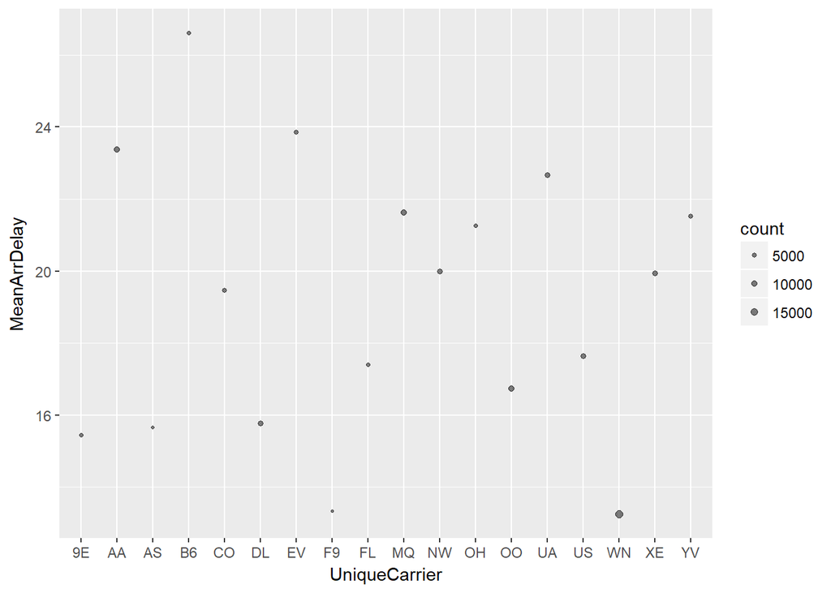

```r
CarrierDelay <- trips %>%
                  group_by(UniqueCarrier) %>%
                  summarise(count=n(), MeanArrDelay = mean(ArrDelay), MeanDepDelay=mean(DepDelay), MeanNASDelay=mean(NASDelay)) %>%
                  filter ( count > 1000, !is.na(MeanArrDelay), !is.na(MeanDepDelay) ) %>%
                  collect

#plot
ggplot(CarrierDelay, aes(UniqueCarrier, MeanArrDelay)) + geom_point(aes(size=count), alpha=1/2) +  scale_size_area(max_size = 2)
```

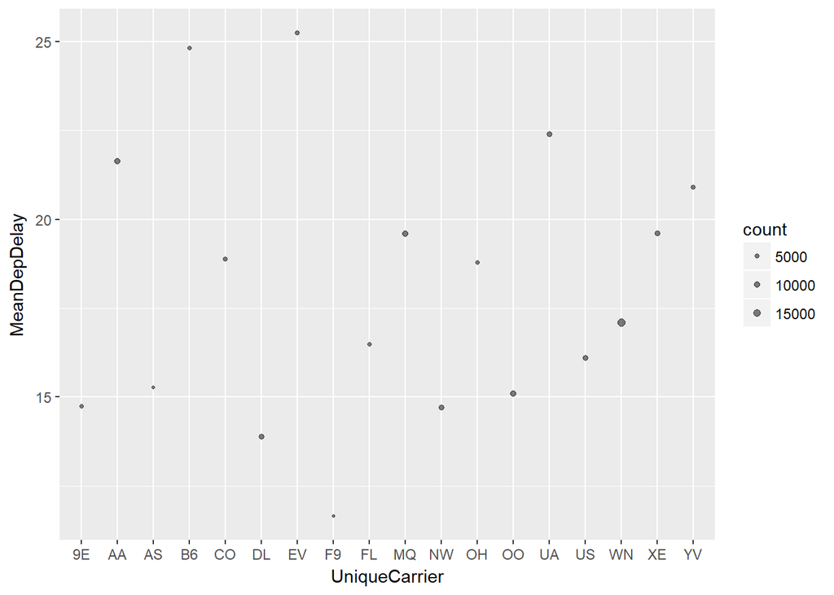

```r
ggplot(CarrierDelay, aes(UniqueCarrier, MeanDepDelay)) + geom_point(aes(size=count), alpha=1/2) +  scale_size_area(max_size = 2)
```

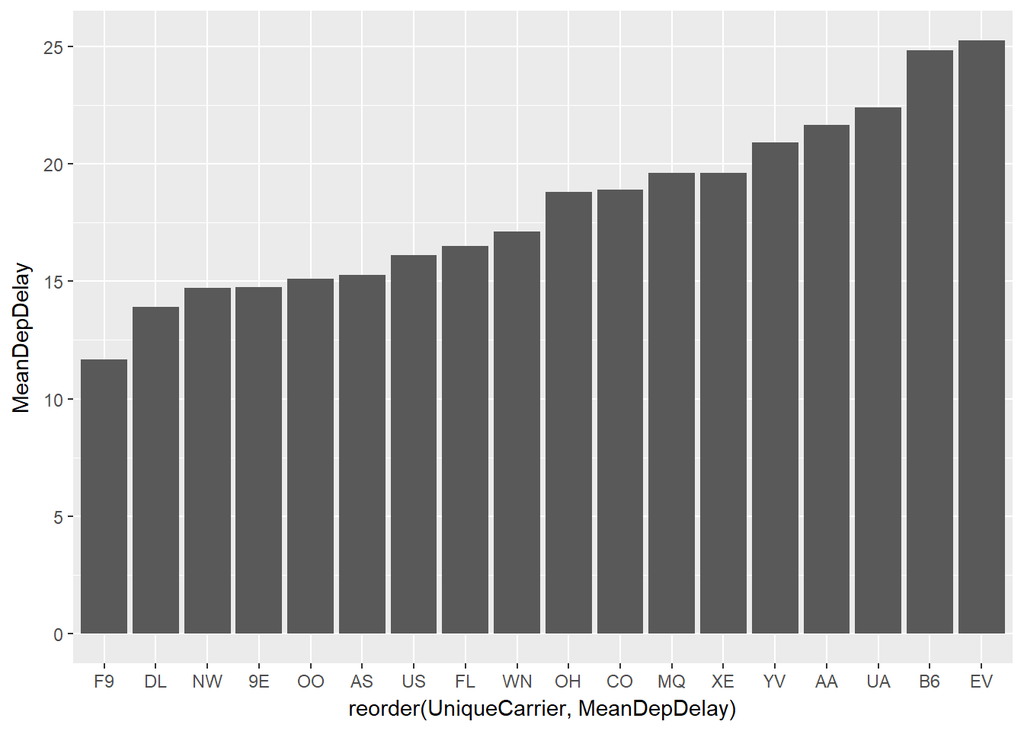

```r
# Same stuff with Bar chart.
ggplot(CarrierDelay, aes(reorder(UniqueCarrier, MeanDepDelay), MeanDepDelay)) + geom_bar( stat = "identity")
```

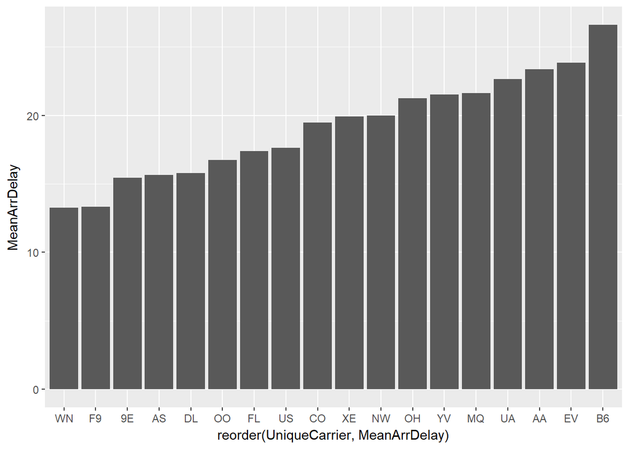

```r
ggplot(CarrierDelay, aes(reorder(UniqueCarrier, MeanArrDelay), MeanArrDelay)) + geom_bar( stat = "identity")
```

Again, Carrier performance differs between Airport to Airport. We can easily apply filter on Airport and get best parforming of Carrier. Or write a simple function to do the same.

#### Origin Airports - Performance

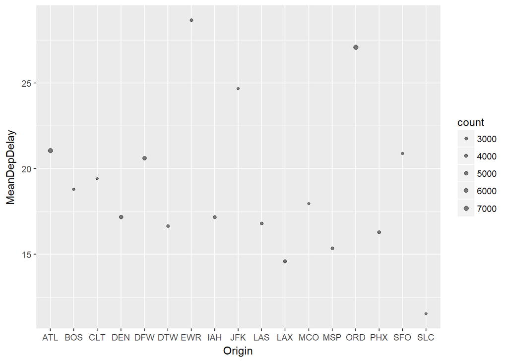

```r
OriginAirportDelay <- trips %>%
  group_by(Origin) %>%
  summarise(count=n(), MeanArrDelay = mean(ArrDelay), MeanDepDelay=mean(DepDelay), MeanWeatherDelay=mean(WeatherDelay)) %>%
  filter ( count > 2000, !is.na(MeanArrDelay), !is.na(MeanDepDelay) ) %>%
  collect
# Increasing count to 2000 for filtering in order to avoid too much cluttering.

#plot
ggplot(OriginAirportDelay, aes(Origin, MeanDepDelay)) + geom_point(aes(size=count), alpha=1/2) + geom_smooth() + scale_size_area(max_size = 2)
```

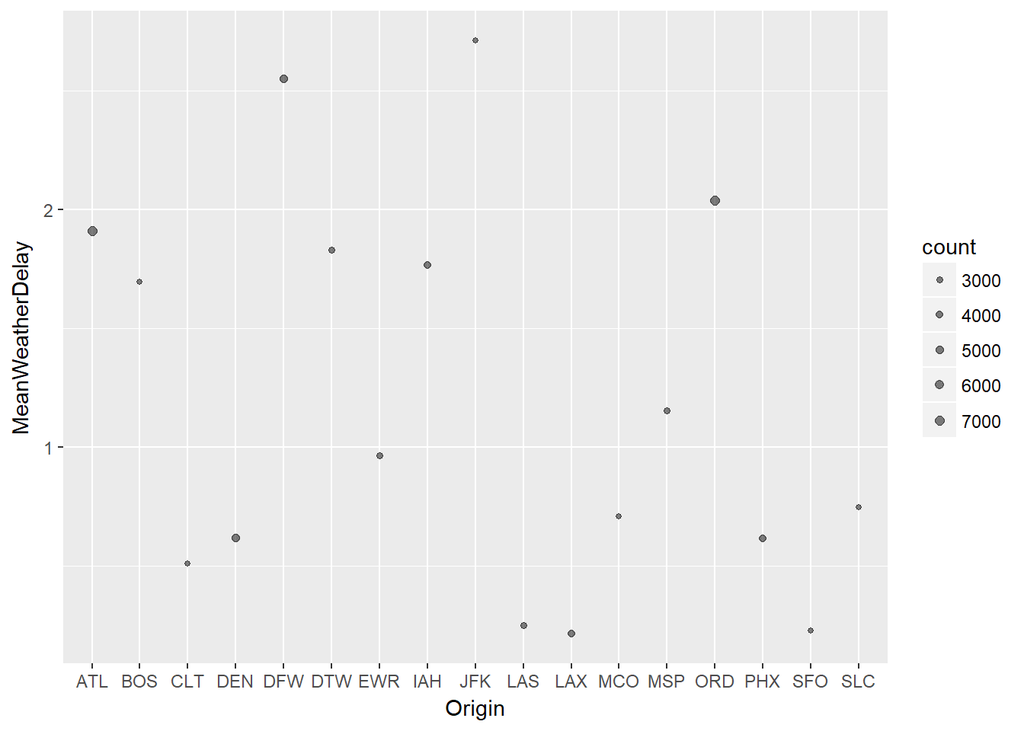

```r
ggplot(OriginAirportDelay, aes(Origin, MeanWeatherDelay)) + geom_point(aes(size=count), alpha=1/2) + geom_smooth() + scale_size_area(max_size = 2)
```

Lax and SLS are doing better for Departure. Weather is also not much impacted at LAX compared to others. However, except these airports, there is no perticular pattern we can observe. May be we need to combine other variables.

##### Dest Airports - performance

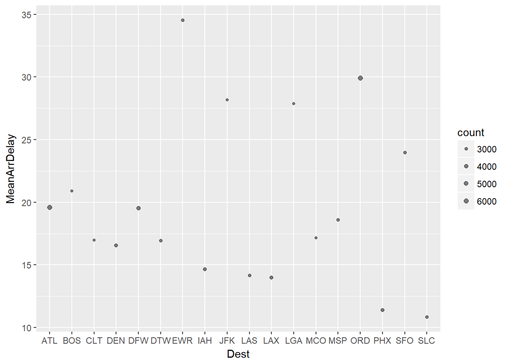

```r
DestAirportDelay <- trips %>%
  group_by(Dest) %>%
  summarise(count=n(), MeanArrDelay = mean(ArrDelay), MeanDepDelay=mean(DepDelay), MeanWeatherDelay2=mean(WeatherDelay)) %>%
  filter ( count > 2000, !is.na(MeanArrDelay), !is.na(MeanDepDelay) ) %>%
  collect
#
#plot
ggplot(DestAirportDelay, aes(Dest, MeanArrDelay)) + geom_point(aes(size=count), alpha=1/2) + geom_smooth() + scale_size_area(max_size = 2)
```

SLC, PHX are doing very good with Arrival. And ORD, LGA, JFK, ESR are not so great.

## When is the best time of the day/week/month/year to travel to minimize delays ?

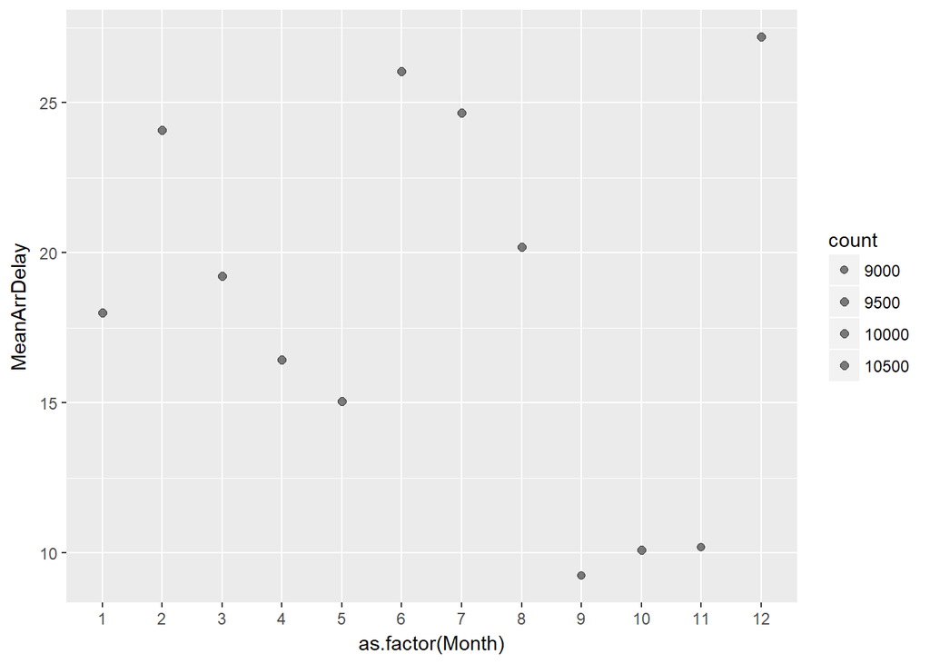

```r
DayMonthDelay <- trips %>%
  group_by(Month) %>%
  summarise(count=n(), MeanArrDelay = mean(ArrDelay), MeanDepDelay=mean(DepDelay), MeanWeatherDelay2=mean(WeatherDelay)) %>%
  filter ( count > 50, !is.na(MeanArrDelay), !is.na(MeanDepDelay) ) %>%
  collect

#plot
ggplot(DayMonthDelay, aes(as.factor(Month), MeanArrDelay)) + geom_point(aes(size=count), alpha=1/2) + geom_smooth() + scale_size_area(max_size = 2)
```

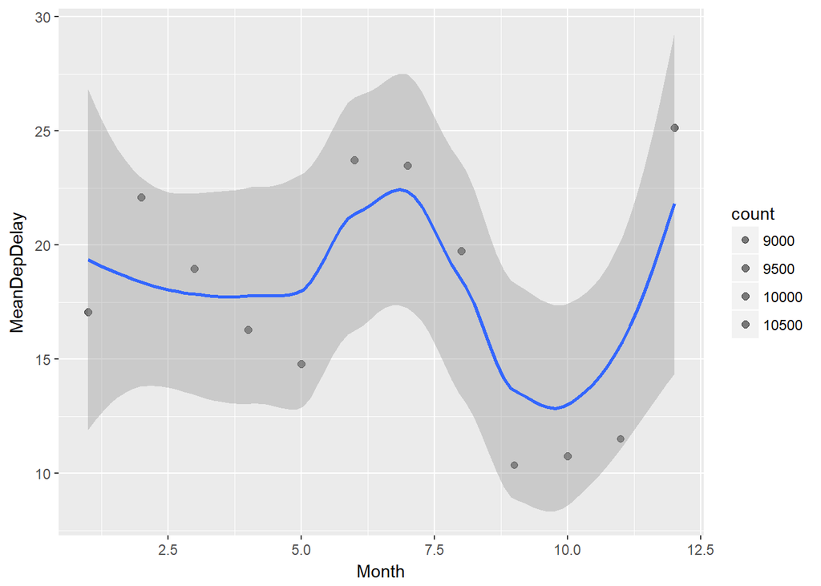

```r
ggplot(DayMonthDelay, aes(Month, MeanDepDelay)) + geom_point(aes(size=count), alpha=1/2) + geom_smooth() + scale_size_area(max_size = 2)
```

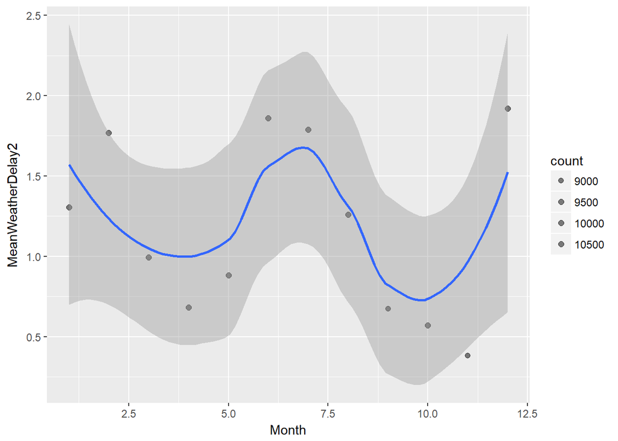

```r
ggplot(DayMonthDelay, aes(Month, MeanWeatherDelay2)) + geom_point(aes(size=count), alpha=1/2) + geom_smooth() + scale_size_area(max_size = 2)
```

We can clearly see Sept, Oct, Nov are the best months to fly as the delays are very min.

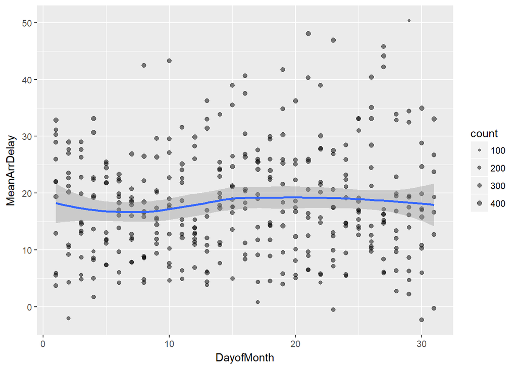

```r
DayofMonthDelay <- trips %>%
  group_by(Month,DayofMonth) %>%
  summarise(count=n(), MeanArrDelay = mean(ArrDelay), MeanDepDelay=mean(DepDelay), MeanWeatherDelay2=mean(WeatherDelay)) %>%
  filter ( count > 50, !is.na(MeanArrDelay), !is.na(MeanDepDelay) ) %>%
  collect

ggplot(DayofMonthDelay, aes(DayofMonth, MeanArrDelay)) + geom_point(aes(size=count), alpha=1/2) + geom_smooth() + scale_size_area(max_size = 2)
```

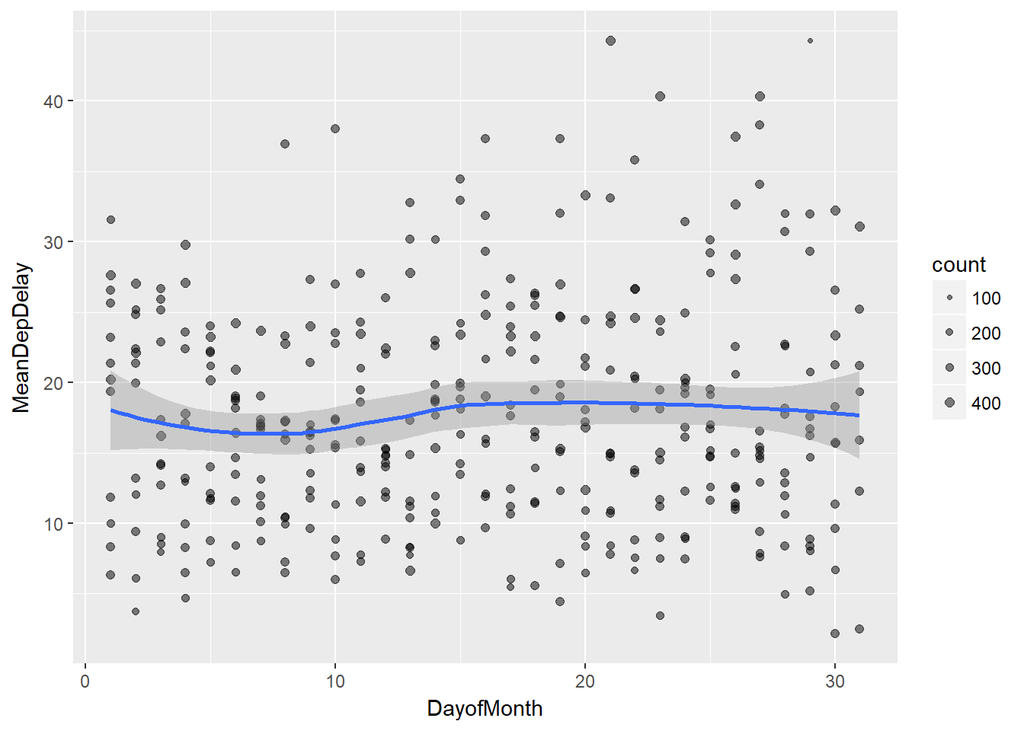

```r
ggplot(DayofMonthDelay, aes(DayofMonth, MeanDepDelay)) + geom_point(aes(size=count), alpha=1/2) + geom_smooth() + scale_size_area(max_size = 2)
```

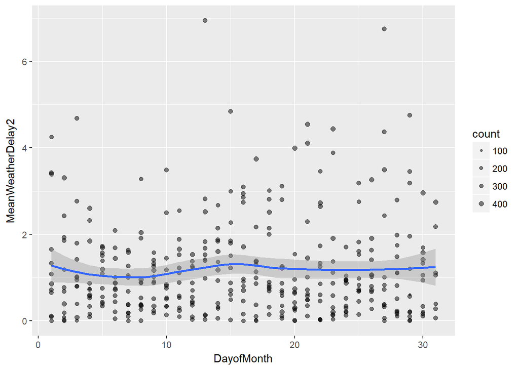

```r
ggplot(DayofMonthDelay, aes(DayofMonth, MeanWeatherDelay2)) + geom_point(aes(size=count), alpha=1/2) + geom_smooth() + scale_size_area(max_size = 2)
```

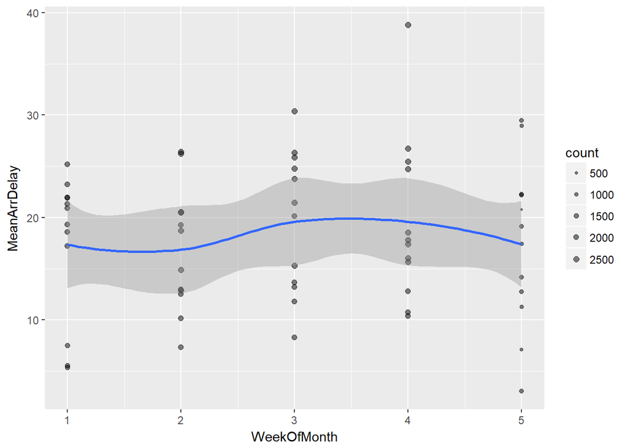

```r
# There is no patteren what so ever. No point in usng this as variable. However, we can try deviding the same by 7 and get the week info to see if there is a patteren.

WeekOfMonthDelay <- trips %>%
  group_by(Month,WeekOfMonth) %>%
  summarise(count=n(), MeanArrDelay = mean(ArrDelay), MeanDepDelay=mean(DepDelay), MeanWeatherDelay2=mean(WeatherDelay)) %>%
  filter ( count > 50, !is.na(MeanArrDelay), !is.na(MeanDepDelay) ) %>%
  collect


ggplot(WeekOfMonthDelay, aes(WeekOfMonth, MeanArrDelay)) + geom_point(aes(size=count), alpha=1/2) + geom_smooth() + scale_size_area(max_size = 2)
```

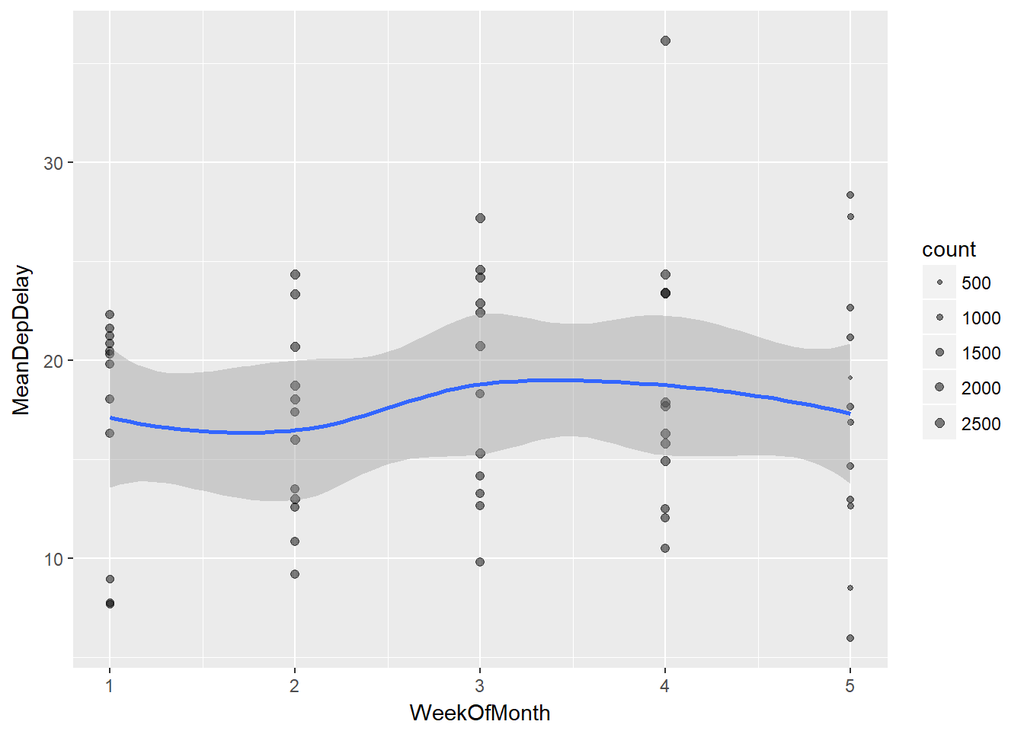

```r
ggplot(WeekOfMonthDelay, aes(WeekOfMonth, MeanDepDelay)) + geom_point(aes(size=count), alpha=1/2) + geom_smooth() + scale_size_area(max_size = 2)
```

You can see overall 2nd week is better in a month and 5th week(i.e month end - 29th, 30th 31st) is better time to fly.

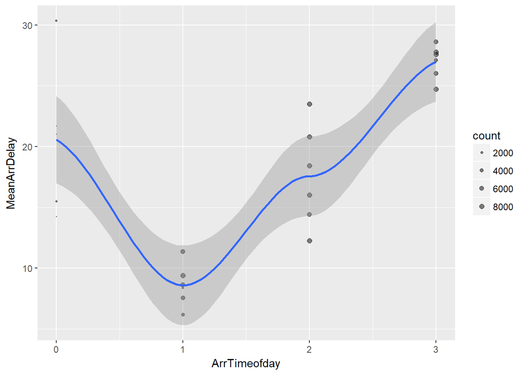

```r
TimeArrDelay <- trips %>%
  group_by(ArrHour,ArrTimeofday) %>%
  summarise(count=n(), MeanArrDelay = mean(ArrDelay), MeanDepDelay=mean(DepDelay), MeanWeatherDelay2=mean(WeatherDelay)) %>%
  filter ( count > 50, !is.na(MeanArrDelay), !is.na(MeanDepDelay) ) %>%
  collect

ggplot(TimeArrDelay, aes(ArrTimeofday, MeanArrDelay)) + geom_point(aes(size=count), alpha=1/2) + geom_smooth() + scale_size_area(max_size = 2)
```

Plan your flight such a way, your sheduled arrival is morning. i.e better overall.

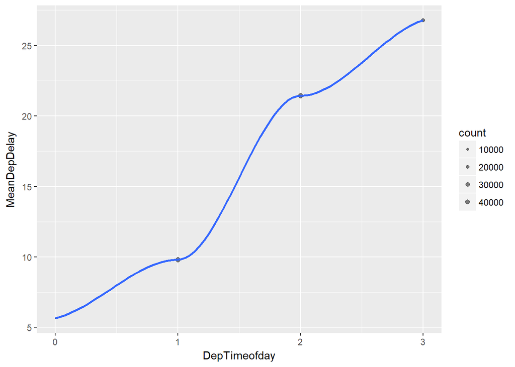

```r
TimeDepDelay <- trips %>%
  group_by(DepTimeofday) %>%
  summarise(count=n(), MeanArrDelay = mean(ArrDelay), MeanDepDelay=mean(DepDelay), MeanWeatherDelay2=mean(WeatherDelay)) %>%
  filter ( count > 50, !is.na(MeanArrDelay), !is.na(MeanDepDelay) ) %>%
  collect

ggplot(TimeDepDelay, aes(DepTimeofday, MeanDepDelay)) + geom_point(aes(size=count), alpha=1/2) + geom_smooth() + scale_size_area(max_size = 2)
```

Generally Departure delays keeps increasing as day prgress. So early morning flights are better.

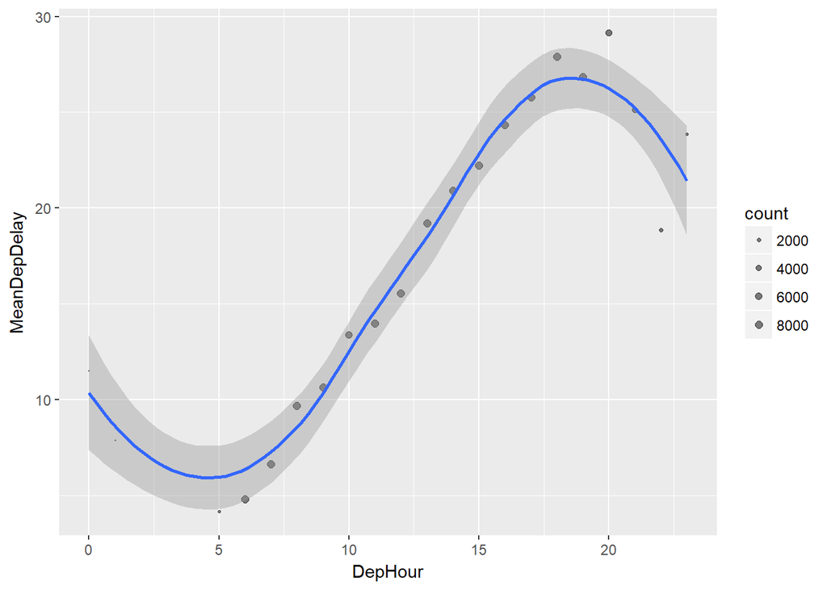

```r
HourDepDelay <- trips %>%
  group_by(DepHour) %>%
  summarise(count=n(), MeanArrDelay = mean(ArrDelay), MeanDepDelay=mean(DepDelay), MeanWeatherDelay2=mean(WeatherDelay)) %>%
  filter ( count > 50, !is.na(MeanArrDelay), !is.na(MeanDepDelay) ) %>%
  collect

ggplot(HourDepDelay, aes(DepHour, MeanDepDelay)) + geom_point(aes(size=count), alpha=1/2) + geom_smooth() + scale_size_area(max_size = 2)
```

Clearly 5-10am departures are better. and almost very negligible delays of less then ~10min.

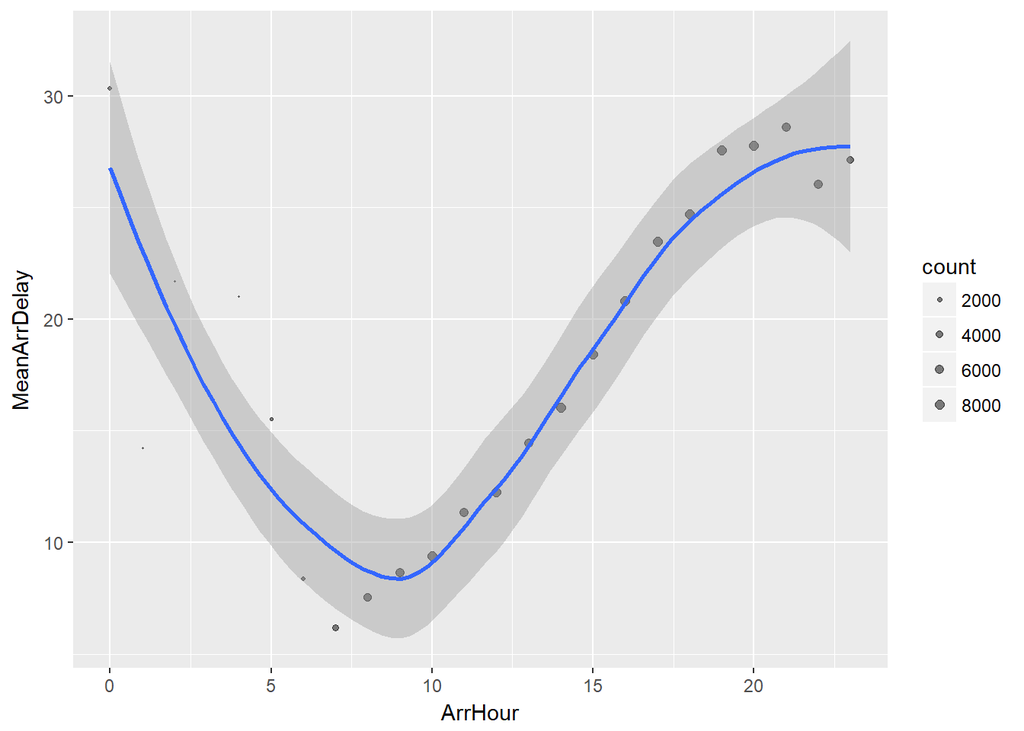

```r
HourArrDelay <- trips %>%
  group_by(ArrHour) %>%
  summarise(count=n(), MeanArrDelay = mean(ArrDelay), MeanDepDelay=mean(DepDelay), MeanWeatherDelay2=mean(WeatherDelay)) %>%
  filter ( count > 50, !is.na(MeanArrDelay), !is.na(MeanDepDelay) ) %>%
  collect

ggplot(HourArrDelay, aes(ArrHour, MeanArrDelay)) + geom_point(aes(size=count), alpha=1/2) + geom_smooth() + scale_size_area(max_size = 2)
```

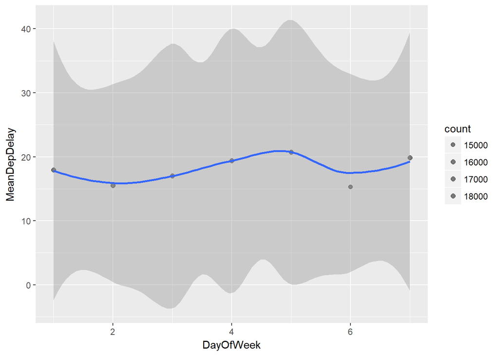

```r
DayOfWeekDelay <- trips %>%
  group_by(DayOfWeek) %>%
  summarise(count=n(), MeanArrDelay = mean(ArrDelay), MeanDepDelay=mean(DepDelay), MeanWeatherDelay2=mean(WeatherDelay)) %>%
  filter ( count > 50, !is.na(MeanArrDelay), !is.na(MeanDepDelay) ) %>%
  collect

ggplot(DayOfWeekDelay, aes(DayOfWeek, MeanDepDelay)) + geom_point(aes(size=count), alpha=1/2) + geom_smooth() + scale_size_area(max_size = 2)
```

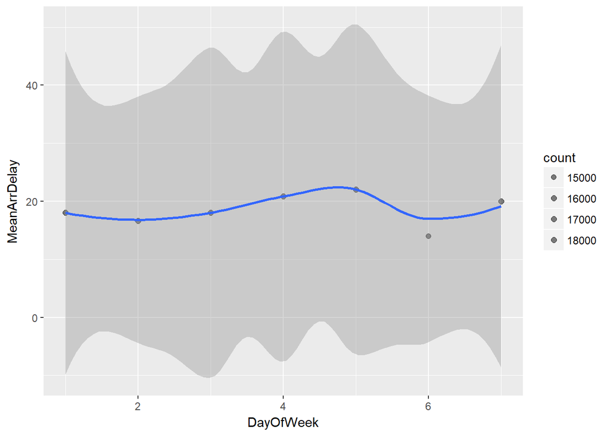

```r
ggplot(DayOfWeekDelay, aes(DayOfWeek, MeanArrDelay)) + geom_point(aes(size=count), alpha=1/2) + geom_smooth() + scale_size_area(max_size = 2)
```

#### Best Time of the day: 5am to 10 am is best for both Departure and Arrival: ~ 10 min delay.

Note: This can differ from airport to airport and carrier to carrier. This is in-general with out specifically considering any of the conditions. If, we want to find based on a condition then we can do the same, by using additonal condition.

## Do older planes suffer more delays ?

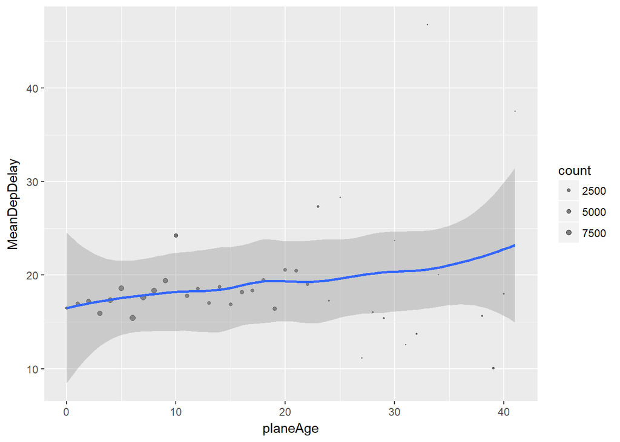

```r
planeAgeDelay <- tripsplaneairports %>%
  filter(planeAge < 1500) %>%
  group_by(planeAge) %>%
  summarise(count=n(), MeanArrDelay = mean(ArrDelay), MeanDepDelay=mean(DepDelay), MeanWeatherDelay2=mean(WeatherDelay)) %>%
  filter ( count > 50, !is.na(MeanArrDelay), !is.na(MeanDepDelay) ) %>%
  collect

ggplot(planeAgeDelay, aes(planeAge, MeanDepDelay)) + geom_point(aes(size=count), alpha=1/2) + geom_smooth() + scale_size_area(max_size = 2)
```

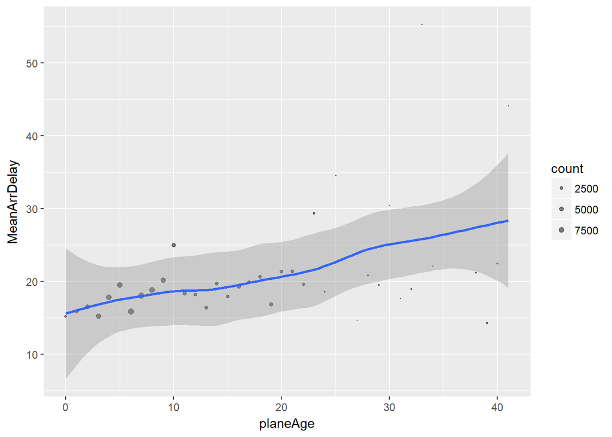

```r
ggplot(planeAgeDelay, aes(planeAge, MeanArrDelay)) + geom_point(aes(size=count), alpha=1/2) + geom_smooth() + scale_size_area(max_size = 2)
```

#### Now let’s look at Airports! This may have importance.

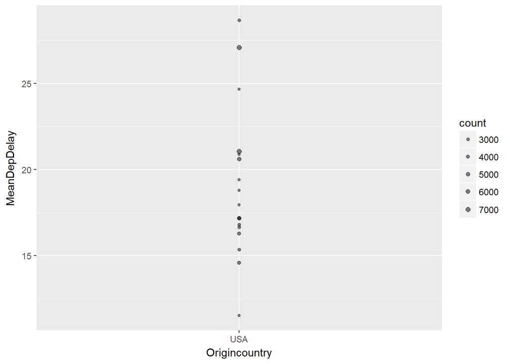

```r
OriginAirportDelay <- tripsplaneairports %>%
  group_by(Origin, Origincity, Originstate, Origincountry) %>%
  summarise(count=n(), MeanArrDelay = mean(ArrDelay), MeanDepDelay=mean(DepDelay), MeanWeatherDelay2=mean(WeatherDelay)) %>%
  filter ( count > 2000, !is.na(MeanArrDelay), !is.na(MeanDepDelay) ) %>%
  collect

# Here increased the count, to study cities/states where major no of trips occoured.

ggplot(OriginAirportDelay, aes(Origincountry, MeanDepDelay)) + geom_point(aes(size=count), alpha=1/2) + geom_smooth() + scale_size_area(max_size = 2)
```

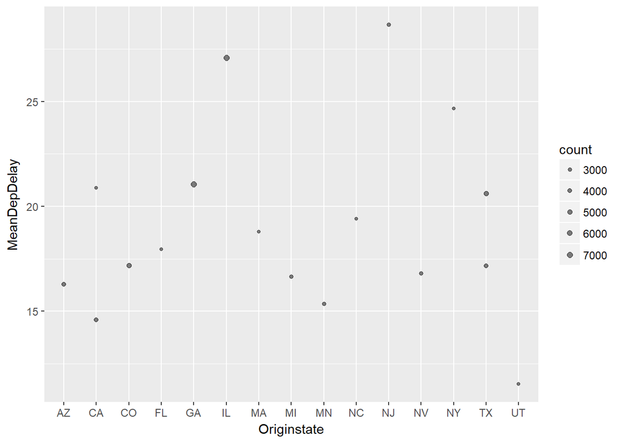

```r
ggplot(OriginAirportDelay, aes(Originstate, MeanDepDelay)) + geom_point(aes(size=count), alpha=1/2) + geom_smooth() + scale_size_area(max_size = 2)
```

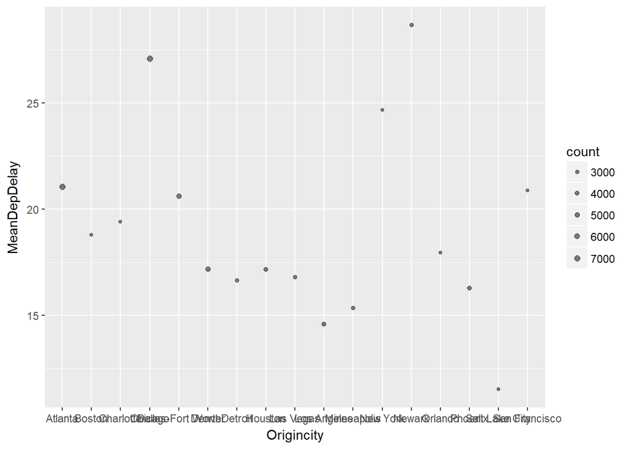

```r
ggplot(OriginAirportDelay, aes(Origincity, MeanDepDelay)) + geom_point(aes(size=count), alpha=1/2) + geom_smooth() + scale_size_area(max_size = 2)
```

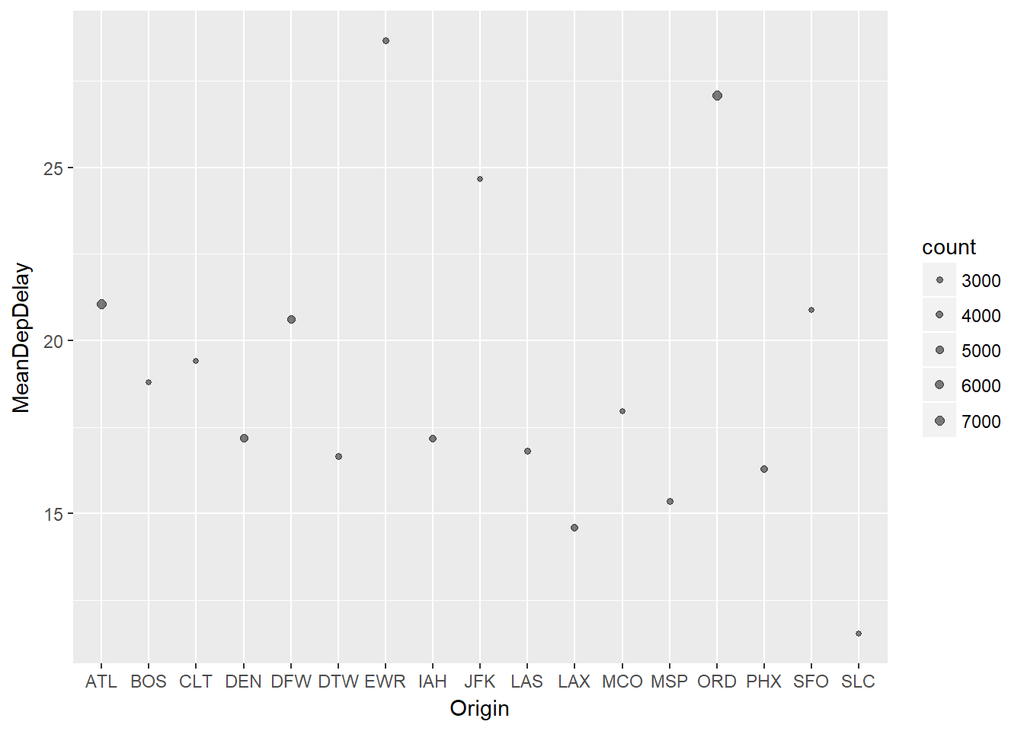

```r
ggplot(OriginAirportDelay, aes(Origin, MeanDepDelay)) + geom_point(aes(size=count), alpha=1/2) + geom_smooth() + scale_size_area(max_size = 2)
```

```r
str(tripsplaneairports)
```

```
## Classes 'data.table' and 'data.frame':   119495 obs. of  46 variables:
##  $ Dest             : Factor w/ 304 levels "ABE","ABI","ABQ",..: 1 1 1 1 1 1 1 1 1 1 ...
##  $ Origin           : Factor w/ 305 levels "ABE","ABI","ABQ",..: 20 20 20 20 20 20 20 20 20 20 ...
##  $ TailNum          : Factor w/ 5607 levels "80009E","80019E",..: 3787 3787 4263 4693 4722 4758 4758 4772 4827 4851 ...
##  $ Year             : int  2007 2007 2007 2007 2007 2007 2007 2007 2007 2007 ...
##  $ Month            : int  6 12 8 11 2 1 1 6 10 3 ...
##  $ DayofMonth       : int  26 27 20 3 2 12 7 9 29 15 ...
##  $ DayOfWeek        : int  2 4 1 6 5 5 7 6 1 4 ...
##  $ DepTime          : int  1600 1454 2045 1711 935 1510 1525 1530 944 1540 ...
##  $ CRSDepTime       : int  1530 1455 2047 1715 945 1505 1505 1530 944 1506 ...
##  $ ArrTime          : int  1804 1635 2237 1859 1146 1702 1725 1733 1150 1720 ...
##  $ CRSArrTime       : int  1734 1652 2255 1913 1148 1701 1701 1734 1146 1705 ...
##  $ UniqueCarrier    : chr  "EV" "EV" "EV" "EV" ...
##  $ FlightNum        : int  4795 4795 4870 4556 4390 4293 4293 4795 4502 4293 ...
##  $ ActualElapsedTime: int  124 101 112 108 131 112 120 123 126 100 ...
```

[output cut: 34 more lines]

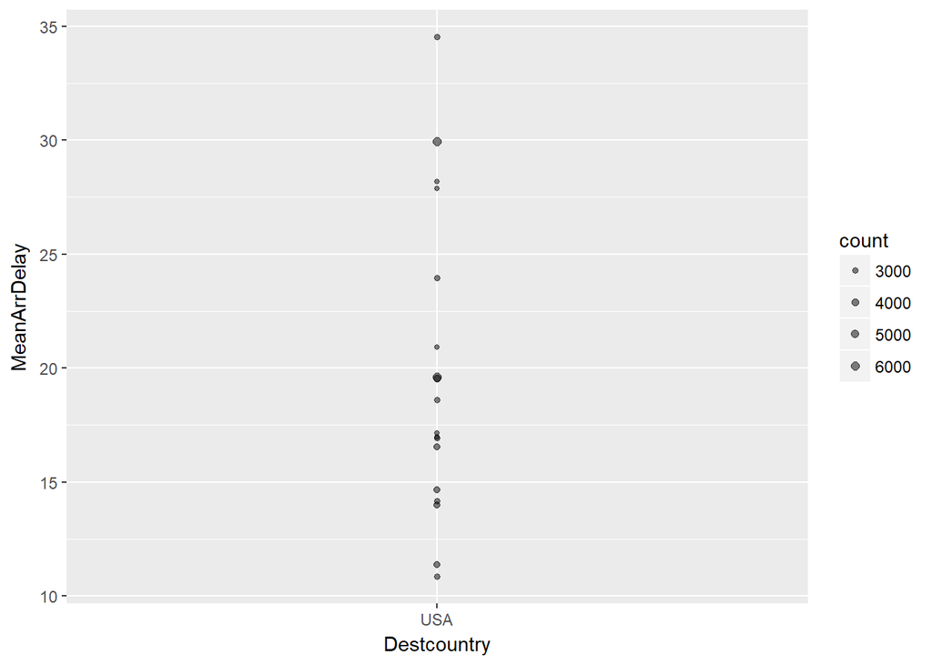

```r
DestAirportDelay <- tripsplaneairports %>%
  group_by(Dest, Destcity, Deststate, Destcountry) %>%
  summarise(count=n(), MeanArrDelay = mean(ArrDelay), MeanDepDelay=mean(DepDelay), MeanWeatherDelay2=mean(WeatherDelay)) %>%
  filter ( count > 2000, !is.na(MeanArrDelay), !is.na(MeanDepDelay) ) %>%
  collect
# Here increased the count, to study cities/states where major no of trips occoured.

ggplot(DestAirportDelay, aes(Destcountry, MeanArrDelay)) + geom_point(aes(size=count), alpha=1/2) + geom_smooth() + scale_size_area(max_size = 2)
```

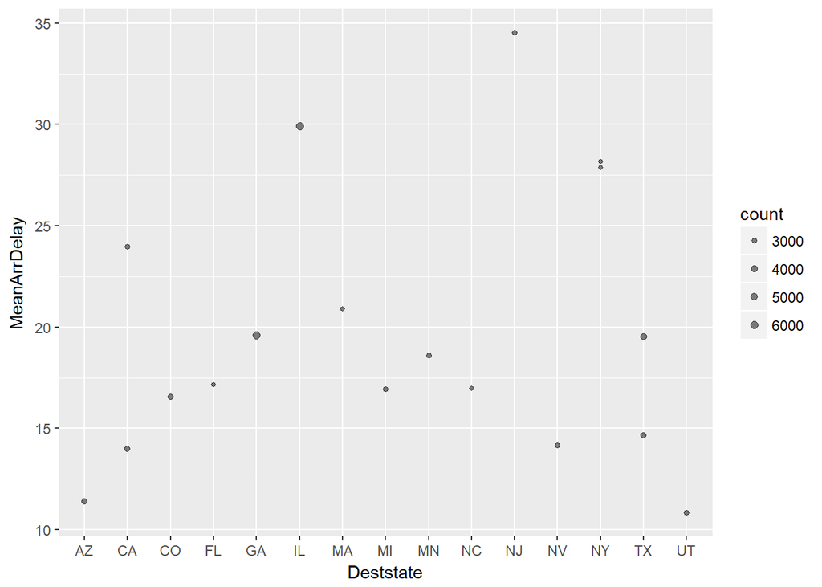

```r
ggplot(DestAirportDelay, aes(Deststate, MeanArrDelay)) + geom_point(aes(size=count), alpha=1/2) + geom_smooth() + scale_size_area(max_size = 2)
```

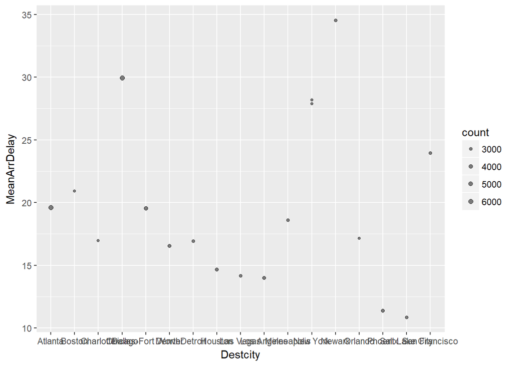

```r
ggplot(DestAirportDelay, aes(Destcity, MeanArrDelay)) + geom_point(aes(size=count), alpha=1/2) + geom_smooth() + scale_size_area(max_size = 2)
```

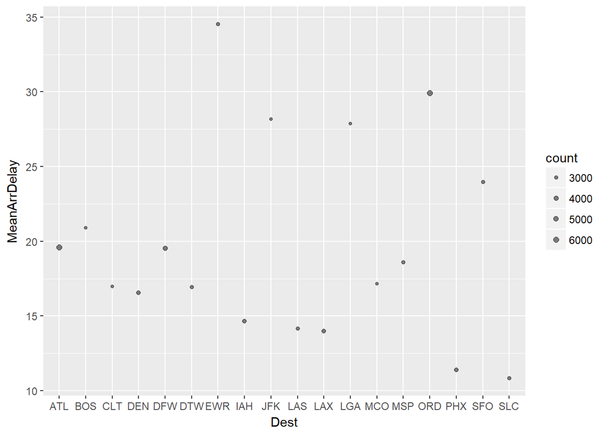

```r
ggplot(DestAirportDelay, aes(Dest, MeanArrDelay)) + geom_point(aes(size=count), alpha=1/2) + geom_smooth() + scale_size_area(max_size = 2)
```

### Let’s plot continous variables and see how they are co-related to each other and to Airline delays.

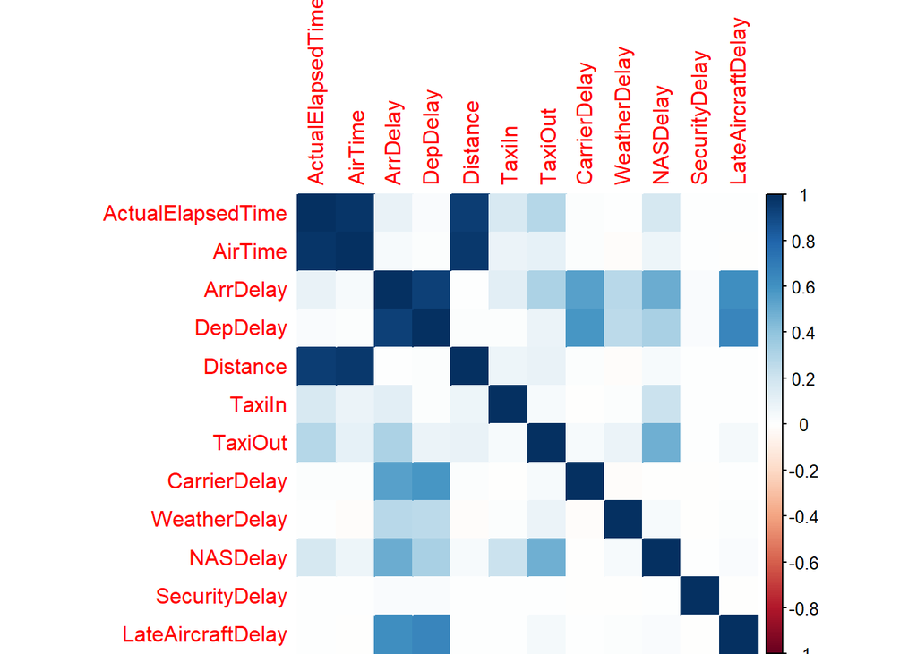

```r
continousdelay <- select(tripsplaneairports, ActualElapsedTime, AirTime, ArrDelay, DepDelay, Distance,
                         TaxiIn, TaxiOut, CarrierDelay, WeatherDelay, NASDelay, SecurityDelay, LateAircraftDelay)
# We can use this as well..
# cont <- sapply(tripsplaneairports, is.numeric)
# tripsplaneairports [, cont]
# How ever if you want to exclude some of the variables then.. manual selection needed
# tripsplaneairports [, -cont] # For remaning , mostly categorical or factor variables.
# If some variables which has numeric values say (1,2,3) for say three different types and should be converted to factor # variables before doing above steps.

tripscorr <- cor(continousdelay, method="pearson")
# Let's plot the co-relation matix
corrplot(tripscorr, method="color")
```

### co-relation matix

This clearly provides co-relation between the variables. Now based on exploratory data analysis, we need to choose the variables that are potentially significant and then start the modeling. Based on this plot, we can see ArrDelay has positive co-relation with DepDelay, TaxiOut, CarrierDelay, NASDelay, WeatherDelay, LateAirCraftDelay And DepDelay has positive co-relation wth TaxiOut, CarrierDelay, NASDelay, WeatherDelay, LateAirCraftDelay So, from continous variable point of view, we got the starting point. We can also see that the significant variables are not co-related to each other. i.e there is no multico-linearity.

#### If the multi-colinirity is present, then we should have addressed. i.e combining variables or picking only most significant one and leaving other. PCA is one of the method to address the same. We don’t need here.

Now we have fair idea, now let us see variable significane and based on the results we can choose the best variable combination. We can also statistically, prove what we saw visually befor choosing the final machine learning model.

```r
modeltrips <- na.omit(tripsplaneairports[,c("Dest","Origin", "Month", "DayOfWeek",  "ArrTime", "UniqueCarrier", "ActualElapsedTime", "CRSElapsedTime",
                                    "TaxiOut", "Diverted",  "CarrierDelay", "WeatherDelay",    "NASDelay",        "SecurityDelay",   "LateAircraftDelay" ,"ArrHour",
                                    "DepHour",         "ArrTimeofday",    "DepTimeofday",       "WeekOfMonth",    "Origincity",
                                    "Originstate",   "Destcity", "Deststate" ,  "ArrDelay", "DepDelay" )])
```

#### See each variable, how significant to the DepDelay and ArrDelay

```r
lm.fit1 <- stats::lm(formula = DepDelay ~ factor(Month), data = modeltrips)
summary(lm.fit1)
```

```
##
## Call:
## stats::lm(formula = DepDelay ~ factor(Month), data = modeltrips)
##
## Residuals:
##     Min      1Q  Median      3Q     Max
##  -68.74  -21.47  -14.48    3.88 1216.21
##
## Coefficients:
##                 Estimate Std. Error t value Pr(>|t|)
## (Intercept)      17.0282     0.4319  39.429  < 2e-16 ***
## factor(Month)2    5.0909     0.6198   8.214  < 2e-16 ***
## factor(Month)3    1.9427     0.6029   3.222 0.001272 **
## factor(Month)4   -0.7614     0.6172  -1.234 0.217368
## factor(Month)5   -2.2345     0.6107  -3.659 0.000254 ***
## factor(Month)6    6.7071     0.6060  11.067  < 2e-16 ***
## factor(Month)7    6.4454     0.6036  10.678  < 2e-16 ***
## factor(Month)8    2.7027     0.6084   4.443 8.89e-06 ***
## factor(Month)9   -6.6927     0.6304 -10.617  < 2e-16 ***
## factor(Month)10  -6.2637     0.6219 -10.072  < 2e-16 ***
## factor(Month)11  -5.5437     0.6283  -8.824  < 2e-16 ***
## factor(Month)12   8.0941     0.6095  13.280  < 2e-16 ***
## ---
## Signif. codes:  0 '***' 0.001 '**' 0.01 '*' 0.05 '.' 0.1 ' ' 1
##
## Residual standard error: 43.48 on 119329 degrees of freedom
## Multiple R-squared:  0.01284,    Adjusted R-squared:  0.01275
## F-statistic: 141.1 on 11 and 119329 DF,  p-value: < 2.2e-16
```

Month seems to be significant as evident in EDA and here with p value less than 0.0001.

```r
lm.fit2 <-  stats::lm(formula = DepDelay ~ factor(DepTimeofday) + factor(DepHour), data = modeltrips)
summary(lm.fit2)
```

```
##
## Call:
## stats::lm(formula = DepDelay ~ factor(DepTimeofday) + factor(DepHour),
##     data = modeltrips)
##
## Residuals:
##     Min      1Q  Median      3Q     Max
##  -65.12  -21.20  -11.67    3.15 1215.43
##
## Coefficients: (3 not defined because of singularities)
##                       Estimate Std. Error t value Pr(>|t|)
## (Intercept)            11.5177     3.6290   3.174  0.00150 **
## factor(DepTimeofday)1   2.4699     3.6621   0.674  0.50002
## factor(DepTimeofday)2  14.2752     3.6594   3.901 9.59e-05 ***
## factor(DepTimeofday)3  12.3470     3.9801   3.102  0.00192 **
## factor(DepHour)1       -3.6364     6.6815  -0.544  0.58627
## factor(DepHour)2       -5.3639    12.4903  -0.429  0.66760
## factor(DepHour)3       -8.5177    17.9625  -0.474  0.63536
## factor(DepHour)4        1.0656    12.9580   0.082  0.93446
## factor(DepHour)5       -7.3620     3.9840  -1.848  0.06462 .
## factor(DepHour)6       -9.2500     0.6943 -13.324  < 2e-16 ***
## factor(DepHour)7       -7.4123     0.6948 -10.668  < 2e-16 ***
## factor(DepHour)8       -4.3148     0.6935  -6.222 4.92e-10 ***
## factor(DepHour)9       -3.3521     0.6947  -4.825 1.40e-06 ***
## factor(DepHour)10      -0.6004     0.7067  -0.850  0.39556
## factor(DepHour)11           NA         NA      NA       NA
## factor(DepHour)12     -10.2200     0.6854 -14.912  < 2e-16 ***
## factor(DepHour)13      -6.5902     0.6770  -9.734  < 2e-16 ***
## factor(DepHour)14      -4.9033     0.6882  -7.125 1.05e-12 ***
## factor(DepHour)15      -3.5772     0.6870  -5.207 1.92e-07 ***
## factor(DepHour)16      -1.4600     0.6750  -2.163  0.03055 *
## factor(DepHour)17           NA         NA      NA       NA
## factor(DepHour)18       4.0344     1.7097   2.360  0.01829 *
## factor(DepHour)19       2.9595     1.7104   1.730  0.08357 .
## factor(DepHour)20       5.2561     1.7424   3.017  0.00256 **
## factor(DepHour)21       1.2578     1.7617   0.714  0.47525
## factor(DepHour)22      -5.0134     1.9830  -2.528  0.01147 *
## factor(DepHour)23           NA         NA      NA       NA
## ---
## Signif. codes:  0 '***' 0.001 '**' 0.01 '*' 0.05 '.' 0.1 ' ' 1
##
## Residual standard error: 43.09 on 119317 degrees of freedom
## Multiple R-squared:  0.03055,    Adjusted R-squared:  0.03036
## F-statistic: 163.5 on 23 and 119317 DF,  p-value: < 2.2e-16
```

Both seems to be signifiant

```r
lm.fit3 <-  stats::lm(formula = DepDelay ~ factor(DepTimeofday) , data = modeltrips)
summary(lm.fit3)
```

```
##
## Call:
## stats::lm(formula = DepDelay ~ factor(DepTimeofday), data = modeltrips)
##
## Residuals:
##     Min      1Q  Median      3Q     Max
##  -66.43  -21.43  -11.79    3.23 1209.57
##
## Coefficients:
##                       Estimate Std. Error t value Pr(>|t|)
## (Intercept)              5.657      1.426   3.967 7.28e-05 ***
## factor(DepTimeofday)1    4.136      1.440   2.872  0.00408 **
## factor(DepTimeofday)2   15.776      1.440  10.956  < 2e-16 ***
## factor(DepTimeofday)3   21.111      1.451  14.553  < 2e-16 ***
## ---
## Signif. codes:  0 '***' 0.001 '**' 0.01 '*' 0.05 '.' 0.1 ' ' 1
##
## Residual standard error: 43.2 on 119337 degrees of freedom
## Multiple R-squared:  0.02532,    Adjusted R-squared:  0.0253
## F-statistic:  1033 on 3 and 119337 DF,  p-value: < 2.2e-16
```

This seems to be significant

```r
lm.fit4 <-  stats::lm(formula = DepDelay ~ factor(DepHour) , data = modeltrips)
summary(lm.fit4)
```

```
##
## Call:
## stats::lm(formula = DepDelay ~ factor(DepHour), data = modeltrips)
##
## Residuals:
##     Min      1Q  Median      3Q     Max
##  -65.12  -21.20  -11.67    3.15 1215.43
##
## Coefficients:
##                   Estimate Std. Error t value Pr(>|t|)
## (Intercept)        11.5177     3.6290   3.174 0.001505 **
## factor(DepHour)1   -3.6364     6.6815  -0.544 0.586273
## factor(DepHour)2   -5.3639    12.4903  -0.429 0.667601
## factor(DepHour)3   -8.5177    17.9625  -0.474 0.635362
## factor(DepHour)4    1.0656    12.9580   0.082 0.934460
## factor(DepHour)5   -7.3620     3.9840  -1.848 0.064622 .
## factor(DepHour)6   -6.7801     3.6620  -1.851 0.064104 .
## factor(DepHour)7   -4.9423     3.6621  -1.350 0.177153
## factor(DepHour)8   -1.8449     3.6619  -0.504 0.614399
## factor(DepHour)9   -0.8821     3.6621  -0.241 0.809644
## factor(DepHour)10   1.8696     3.6644   0.510 0.609914
## factor(DepHour)11   2.4699     3.6621   0.674 0.500016
## factor(DepHour)12   4.0552     3.6630   1.107 0.268263
## factor(DepHour)13   7.6850     3.6615   2.099 0.035829 *
## factor(DepHour)14   9.3719     3.6635   2.558 0.010524 *
## factor(DepHour)15  10.6980     3.6633   2.920 0.003498 **
## factor(DepHour)16  12.8152     3.6611   3.500 0.000465 ***
## factor(DepHour)17  14.2752     3.6594   3.901 9.59e-05 ***
## factor(DepHour)18  16.3814     3.6635   4.472 7.77e-06 ***
## factor(DepHour)19  15.3065     3.6637   4.178 2.95e-05 ***
## factor(DepHour)20  17.6031     3.6788   4.785 1.71e-06 ***
## factor(DepHour)21  13.6048     3.6880   3.689 0.000225 ***
## factor(DepHour)22   7.3336     3.7987   1.931 0.053541 .
## factor(DepHour)23  12.3470     3.9801   3.102 0.001921 **
## ---
## Signif. codes:  0 '***' 0.001 '**' 0.01 '*' 0.05 '.' 0.1 ' ' 1
##
## Residual standard error: 43.09 on 119317 degrees of freedom
## Multiple R-squared:  0.03055,    Adjusted R-squared:  0.03036
## F-statistic: 163.5 on 23 and 119317 DF,  p-value: < 2.2e-16
```

Dep hour seems to be more significant

```r
lm.fit5 <-  stats::lm(formula = DepDelay ~ factor(DayOfWeek) + factor(WeekOfMonth), data = modeltrips)
summary(lm.fit5)
```

```
##
## Call:
## stats::lm(formula = DepDelay ~ factor(DayOfWeek) + factor(WeekOfMonth),
##     data = modeltrips)
##
## Residuals:
##     Min      1Q  Median      3Q     Max
##  -64.08  -21.37  -16.37    4.01 1211.68
##
## Coefficients:
##                      Estimate Std. Error t value Pr(>|t|)
## (Intercept)          17.40849    0.41585  41.863  < 2e-16 ***
## factor(DayOfWeek)2   -2.47925    0.46800  -5.298 1.18e-07 ***
## factor(DayOfWeek)3   -0.96562    0.46782  -2.064  0.03901 *
## factor(DayOfWeek)4    1.43288    0.46504   3.081  0.00206 **
## factor(DayOfWeek)5    2.78106    0.46205   6.019 1.76e-09 ***
## factor(DayOfWeek)6   -2.70660    0.48709  -5.557 2.76e-08 ***
## factor(DayOfWeek)7    1.90993    0.47121   4.053 5.05e-05 ***
## factor(WeekOfMonth)2 -0.86168    0.38822  -2.220  0.02645 *
## factor(WeekOfMonth)3  1.60371    0.38841   4.129 3.65e-05 ***
## factor(WeekOfMonth)4  1.66691    0.38910   4.284 1.84e-05 ***
## factor(WeekOfMonth)5 -0.05274    0.47642  -0.111  0.91186
## ---
## Signif. codes:  0 '***' 0.001 '**' 0.01 '*' 0.05 '.' 0.1 ' ' 1
##
## Residual standard error: 43.71 on 119330 degrees of freedom
## Multiple R-squared:  0.0026, Adjusted R-squared:  0.002517
## F-statistic: 31.11 on 10 and 119330 DF,  p-value: < 2.2e-16
```

The variance it is explaining is very small.

Now let’s combine by adding these together and check significance.

```r
lm.fit.com.1 <- stats::lm(formula = DepDelay ~ factor(Month) + factor(WeekOfMonth)  , data = modeltrips)
summary(lm.fit.com.1)
```

```
##
## Call:
## stats::lm(formula = DepDelay ~ factor(Month) + factor(WeekOfMonth),
##     data = modeltrips)
##
## Residuals:
##     Min      1Q  Median      3Q     Max
##  -69.72  -21.47  -14.39    3.72 1216.76
##
## Coefficients:
##                      Estimate Std. Error t value Pr(>|t|)
## (Intercept)           16.4785     0.4996  32.985  < 2e-16 ***
## factor(Month)2         5.0670     0.6207   8.164 3.27e-16 ***
## factor(Month)3         1.9533     0.6028   3.240 0.001195 **
## factor(Month)4        -0.7380     0.6173  -1.196 0.231844
## factor(Month)5        -2.2373     0.6107  -3.664 0.000249 ***
## factor(Month)6         6.7021     0.6061  11.058  < 2e-16 ***
## factor(Month)7         6.4507     0.6036  10.687  < 2e-16 ***
## factor(Month)8         2.7148     0.6083   4.463 8.08e-06 ***
## factor(Month)9        -6.7027     0.6305 -10.631  < 2e-16 ***
## factor(Month)10       -6.2618     0.6218 -10.070  < 2e-16 ***
## factor(Month)11       -5.5177     0.6283  -8.782  < 2e-16 ***
## factor(Month)12        8.0197     0.6095  13.158  < 2e-16 ***
## factor(WeekOfMonth)2  -0.7761     0.3862  -2.010 0.044459 *
## factor(WeekOfMonth)3   1.5540     0.3864   4.022 5.77e-05 ***
## factor(WeekOfMonth)4   1.5385     0.3870   3.975 7.03e-05 ***
## factor(WeekOfMonth)5   0.1767     0.4746   0.372 0.709617
## ---
## Signif. codes:  0 '***' 0.001 '**' 0.01 '*' 0.05 '.' 0.1 ' ' 1
##
## Residual standard error: 43.47 on 119325 degrees of freedom
## Multiple R-squared:  0.01333,    Adjusted R-squared:  0.0132
## F-statistic: 107.4 on 15 and 119325 DF,  p-value: < 2.2e-16
```

Increase in R-Squared is not visible ~ 0.1%

```r
lm.fit.com.2 <- stats::lm(formula = DepDelay ~ factor(Month) + factor(WeekOfMonth) + factor(DayOfWeek) , data = modeltrips)
summary(lm.fit.com.2)
```

```
##
## Call:
## stats::lm(formula = DepDelay ~ factor(Month) + factor(WeekOfMonth) +
##     factor(DayOfWeek), data = modeltrips)
##
## Residuals:
##     Min      1Q  Median      3Q     Max
##  -69.57  -21.44  -14.15    3.68 1214.97
##
## Coefficients:
##                      Estimate Std. Error t value Pr(>|t|)
## (Intercept)           16.4126     0.5824  28.183  < 2e-16 ***
## factor(Month)2         4.9489     0.6202   7.980 1.47e-15 ***
## factor(Month)3         1.8569     0.6027   3.081 0.002062 **
## factor(Month)4        -0.9472     0.6171  -1.535 0.124785
## factor(Month)5        -2.3181     0.6101  -3.800 0.000145 ***
## factor(Month)6         6.6195     0.6059  10.926  < 2e-16 ***
## factor(Month)7         6.4472     0.6032  10.688  < 2e-16 ***
## factor(Month)8         2.5552     0.6079   4.203 2.63e-05 ***
## factor(Month)9        -6.7401     0.6303 -10.694  < 2e-16 ***
## factor(Month)10       -6.2952     0.6212 -10.134  < 2e-16 ***
## factor(Month)11       -5.7278     0.6279  -9.122  < 2e-16 ***
## factor(Month)12        7.9989     0.6093  13.129  < 2e-16 ***
## factor(WeekOfMonth)2  -0.8285     0.3859  -2.147 0.031772 *
## factor(WeekOfMonth)3   1.5450     0.3861   4.002 6.28e-05 ***
## factor(WeekOfMonth)4   1.5404     0.3867   3.983 6.81e-05 ***
## factor(WeekOfMonth)5   0.1476     0.4745   0.311 0.755829
## factor(DayOfWeek)2    -2.3263     0.4652  -5.000 5.73e-07 ***
## factor(DayOfWeek)3    -0.7619     0.4651  -1.638 0.101347
## factor(DayOfWeek)4     1.6592     0.4624   3.588 0.000333 ***
## factor(DayOfWeek)5     2.9389     0.4595   6.396 1.60e-10 ***
## factor(DayOfWeek)6    -2.8046     0.4844  -5.790 7.05e-09 ***
## factor(DayOfWeek)7     1.9339     0.4684   4.129 3.64e-05 ***
## ---
## Signif. codes:  0 '***' 0.001 '**' 0.01 '*' 0.05 '.' 0.1 ' ' 1
##
## Residual standard error: 43.43 on 119319 degrees of freedom
## Multiple R-squared:  0.01544,    Adjusted R-squared:  0.01526
## F-statistic: 89.09 on 21 and 119319 DF,  p-value: < 2.2e-16
```

```r
lm.fit.com.3 <- stats::lm(formula = DepDelay ~  factor(Month) + factor(DepHour) , data = modeltrips)
summary(lm.fit.com.3)
```

```
##
## Call:
## stats::lm(formula = DepDelay ~ factor(Month) + factor(DepHour),
##     data = modeltrips)
##
## Residuals:
##     Min      1Q  Median      3Q     Max
##  -69.67  -21.03  -11.50    3.05 1218.61
##
## Coefficients:
##                   Estimate Std. Error t value Pr(>|t|)
## (Intercept)         9.8840     3.6305   2.723 0.006479 **
## factor(Month)2      4.9123     0.6105   8.047 8.57e-16 ***
## factor(Month)3      1.9506     0.5938   3.285 0.001020 **
## factor(Month)4     -0.7068     0.6079  -1.163 0.244980
## factor(Month)5     -2.2433     0.6016  -3.729 0.000192 ***
## factor(Month)6      6.5581     0.5969  10.987  < 2e-16 ***
## factor(Month)7      6.1512     0.5946  10.346  < 2e-16 ***
## factor(Month)8      2.6632     0.5992   4.444 8.82e-06 ***
## factor(Month)9     -6.4666     0.6209 -10.414  < 2e-16 ***
## factor(Month)10    -5.9743     0.6126  -9.753  < 2e-16 ***
## factor(Month)11    -5.3353     0.6188  -8.622  < 2e-16 ***
## factor(Month)12     8.1356     0.6003  13.552  < 2e-16 ***
## factor(DepHour)1   -3.9617     6.6402  -0.597 0.550756
## factor(DepHour)2   -7.1219    12.4129  -0.574 0.566137
## factor(DepHour)3   -9.1072    17.8510  -0.510 0.609929
## factor(DepHour)4    2.3657    12.8779   0.184 0.854248
## factor(DepHour)5   -6.4321     3.9594  -1.625 0.104265
## factor(DepHour)6   -5.9407     3.6394  -1.632 0.102607
## factor(DepHour)7   -4.3083     3.6395  -1.184 0.236502
## factor(DepHour)8   -1.0828     3.6392  -0.298 0.766058
## factor(DepHour)9   -0.0897     3.6394  -0.025 0.980337
## factor(DepHour)10   2.4842     3.6417   0.682 0.495136
## factor(DepHour)11   3.1920     3.6394   0.877 0.380459
## factor(DepHour)12   4.7474     3.6404   1.304 0.192197
## factor(DepHour)13   8.2316     3.6388   2.262 0.023689 *
## factor(DepHour)14   9.9135     3.6409   2.723 0.006473 **
## factor(DepHour)15  11.3021     3.6406   3.104 0.001907 **
## factor(DepHour)16  13.4766     3.6384   3.704 0.000212 ***
## factor(DepHour)17  14.8297     3.6367   4.078 4.55e-05 ***
## factor(DepHour)18  16.9467     3.6408   4.655 3.25e-06 ***
## factor(DepHour)19  15.8330     3.6411   4.348 1.37e-05 ***
## factor(DepHour)20  18.1152     3.6561   4.955 7.25e-07 ***
## factor(DepHour)21  14.0296     3.6651   3.828 0.000129 ***
## factor(DepHour)22   7.7879     3.7751   2.063 0.039117 *
## factor(DepHour)23  12.5006     3.9554   3.160 0.001576 **
## ---
## Signif. codes:  0 '***' 0.001 '**' 0.01 '*' 0.05 '.' 0.1 ' ' 1
##
## Residual standard error: 42.82 on 119306 degrees of freedom
## Multiple R-squared:  0.0427, Adjusted R-squared:  0.04242
## F-statistic: 156.5 on 34 and 119306 DF,  p-value: < 2.2e-16
```

Out of above variables, Month adn DepHour seems to be predicting better.

```r
lm.fit.com.3 <- stats::lm(formula = DepDelay ~  factor(Month) +  factor(ArrHour) , data = modeltrips)
summary(lm.fit.com.3)
```

```
##
## Call:
## stats::lm(formula = DepDelay ~ factor(Month) + factor(ArrHour),
##     data = modeltrips)
##
## Residuals:
##     Min      1Q  Median      3Q     Max
##  -70.62  -20.93  -11.48    2.92 1220.33
##
## Coefficients:
##                   Estimate Std. Error t value Pr(>|t|)
## (Intercept)        32.1845     1.5213  21.156  < 2e-16 ***
## factor(Month)2      4.8394     0.6105   7.927 2.26e-15 ***
## factor(Month)3      1.9366     0.5939   3.261 0.001111 **
## factor(Month)4     -0.7147     0.6080  -1.175 0.239828
## factor(Month)5     -2.1562     0.6016  -3.584 0.000338 ***
## factor(Month)6      6.6154     0.5970  11.082  < 2e-16 ***
## factor(Month)7      6.2332     0.5946  10.483  < 2e-16 ***
## factor(Month)8      2.6376     0.5993   4.401 1.08e-05 ***
## factor(Month)9     -6.3956     0.6210 -10.299  < 2e-16 ***
## factor(Month)10    -5.9147     0.6126  -9.655  < 2e-16 ***
## factor(Month)11    -5.3654     0.6188  -8.670  < 2e-16 ***
## factor(Month)12     8.1473     0.6003  13.571  < 2e-16 ***
## factor(ArrHour)1  -14.8322     3.7592  -3.946 7.97e-05 ***
## factor(ArrHour)2   -9.1553     6.1168  -1.497 0.134461
## factor(ArrHour)3  -14.1507     7.5974  -1.863 0.062527 .
## factor(ArrHour)4  -10.7589     5.0655  -2.124 0.033676 *
## factor(ArrHour)5  -17.5661     2.2682  -7.745 9.67e-15 ***
## factor(ArrHour)6  -24.6188     1.9363 -12.715  < 2e-16 ***
## factor(ArrHour)7  -27.6494     1.6269 -16.995  < 2e-16 ***
## factor(ArrHour)8  -26.8769     1.5698 -17.121  < 2e-16 ***
## factor(ArrHour)9  -25.7257     1.5597 -16.494  < 2e-16 ***
## factor(ArrHour)10 -24.5747     1.5454 -15.902  < 2e-16 ***
## factor(ArrHour)11 -22.0305     1.5481 -14.230  < 2e-16 ***
## factor(ArrHour)12 -20.8685     1.5444 -13.512  < 2e-16 ***
## factor(ArrHour)13 -19.3626     1.5535 -12.464  < 2e-16 ***
## factor(ArrHour)14 -17.3352     1.5450 -11.221  < 2e-16 ***
## factor(ArrHour)15 -15.4646     1.5474  -9.994  < 2e-16 ***
## factor(ArrHour)16 -13.1758     1.5370  -8.572  < 2e-16 ***
## factor(ArrHour)17 -10.6688     1.5431  -6.914 4.74e-12 ***
## factor(ArrHour)18  -9.9040     1.5395  -6.433 1.25e-10 ***
## factor(ArrHour)19  -7.0419     1.5447  -4.559 5.15e-06 ***
## factor(ArrHour)20  -6.4656     1.5380  -4.204 2.63e-05 ***
## factor(ArrHour)21  -5.1668     1.5517  -3.330 0.000870 ***
## factor(ArrHour)22  -6.6491     1.5635  -4.253 2.11e-05 ***
## factor(ArrHour)23  -5.3741     1.6164  -3.325 0.000885 ***
## ---
## Signif. codes:  0 '***' 0.001 '**' 0.01 '*' 0.05 '.' 0.1 ' ' 1
##
## Residual standard error: 42.82 on 119306 degrees of freedom
## Multiple R-squared:  0.04262,    Adjusted R-squared:  0.04234
## F-statistic: 156.2 on 34 and 119306 DF,  p-value: < 2.2e-16
```

```r
lm.fit6 <-  stats::lm(formula = DepDelay ~ factor(UniqueCarrier),  data = modeltrips)
summary(lm.fit6)
```

```
##
## Call:
## stats::lm(formula = DepDelay ~ factor(UniqueCarrier), data = modeltrips)
##
## Residuals:
##     Min      1Q  Median      3Q     Max
##  -69.82  -21.15  -15.82    4.12 1216.28
##
## Coefficients:
##                         Estimate Std. Error t value Pr(>|t|)
## (Intercept)              14.6162     0.6846  21.351  < 2e-16 ***
## factor(UniqueCarrier)AA   7.0236     0.8066   8.707  < 2e-16 ***
## factor(UniqueCarrier)AQ -13.2873     1.9174  -6.930 4.23e-12 ***
## factor(UniqueCarrier)AS   0.6552     1.1110   0.590   0.5554
## factor(UniqueCarrier)B6  10.2053     1.0253   9.954  < 2e-16 ***
## factor(UniqueCarrier)CO   4.2684     0.9089   4.696 2.66e-06 ***
## factor(UniqueCarrier)DL  -0.7263     0.8454  -0.859   0.3903
## factor(UniqueCarrier)EV  10.4853     0.9354  11.209  < 2e-16 ***
## factor(UniqueCarrier)F9  -2.9585     1.2615  -2.345   0.0190 *
## factor(UniqueCarrier)FL   1.8700     0.9564   1.955   0.0506 .
## factor(UniqueCarrier)HA -11.0513     1.6286  -6.786 1.16e-11 ***
## factor(UniqueCarrier)MQ   4.9382     0.8309   5.943 2.80e-09 ***
## factor(UniqueCarrier)NW   0.1014     0.8695   0.117   0.9071
## factor(UniqueCarrier)OH   4.2029     0.9825   4.278 1.89e-05 ***
## factor(UniqueCarrier)OO   0.5301     0.8208   0.646   0.5184
## factor(UniqueCarrier)UA   7.7784     0.8408   9.251  < 2e-16 ***
## factor(UniqueCarrier)US   1.4970     0.8471   1.767   0.0772 .
## factor(UniqueCarrier)WN   2.4855     0.7556   3.290   0.0010 **
## factor(UniqueCarrier)XE   4.9905     0.8662   5.761 8.37e-09 ***
## factor(UniqueCarrier)YV   6.3482     0.9365   6.779 1.22e-11 ***
## ---
## Signif. codes:  0 '***' 0.001 '**' 0.01 '*' 0.05 '.' 0.1 ' ' 1
##
## Residual standard error: 43.61 on 119321 degrees of freedom
## Multiple R-squared:  0.006892,   Adjusted R-squared:  0.006733
## F-statistic: 43.58 on 19 and 119321 DF,  p-value: < 2.2e-16
```

Through p-value they seem to be significant, not when we look for R-squared. Let’s proceed further.

```r
lm.fit7 <-  stats::lm(formula = DepDelay ~ factor(Originstate) ,  data = modeltrips)
summary(lm.fit7)
```

```
##
## Call:
## stats::lm(formula = DepDelay ~ factor(Originstate), data = modeltrips)
##
## Residuals:
##     Min      1Q  Median      3Q     Max
##  -63.70  -21.24  -15.42    4.12 1208.85
##
## Coefficients:
##                       Estimate Std. Error t value Pr(>|t|)
## (Intercept)            16.6445     1.6955   9.817  < 2e-16 ***
## factor(Originstate)AL  -1.0046     2.3199  -0.433 0.664974
## factor(Originstate)AR  -1.3511     2.5260  -0.535 0.592736
## factor(Originstate)AZ  -1.2206     1.8331  -0.666 0.505496
## factor(Originstate)CA  -2.2587     1.7356  -1.301 0.193124
## factor(Originstate)CO   0.9183     1.8113   0.507 0.612155
## factor(Originstate)CT  -0.5282     2.5851  -0.204 0.838089
## factor(Originstate)DE  -4.4445    19.5686  -0.227 0.820328
## factor(Originstate)FL   2.0586     1.7646   1.167 0.243362
## factor(Originstate)GA   4.3480     1.7701   2.456 0.014036 *
## factor(Originstate)HI -10.4444     1.9541  -5.345 9.06e-08 ***
## factor(Originstate)IA  -0.9030     2.5471  -0.355 0.722935
## factor(Originstate)ID  -6.7911     2.7281  -2.489 0.012802 *
## factor(Originstate)IL   9.0785     1.7635   5.148 2.64e-07 ***
## factor(Originstate)IN   1.0514     2.1986   0.478 0.632501
## factor(Originstate)KS  -1.9890     3.4593  -0.575 0.565321
## factor(Originstate)KY  -1.0453     1.9302  -0.542 0.588143
## factor(Originstate)LA  -0.8475     2.1550  -0.393 0.694139
## factor(Originstate)MA   2.1841     1.9423   1.124 0.260813
## factor(Originstate)MD   1.4061     1.9917   0.706 0.480207
## factor(Originstate)ME   3.2326     3.6730   0.880 0.378804
## factor(Originstate)MI  -0.6212     1.8462  -0.336 0.736534
## factor(Originstate)MN  -1.3408     1.9033  -0.704 0.481144
## factor(Originstate)MO   1.0925     1.9256   0.567 0.570480
## factor(Originstate)MS   2.8901     2.8528   1.013 0.311026
## factor(Originstate)MT -12.5337     2.9533  -4.244 2.20e-05 ***
## factor(Originstate)NC   1.7061     1.8469   0.924 0.355629
## factor(Originstate)ND   3.6447     3.7845   0.963 0.335519
## factor(Originstate)NE   0.3373     2.5926   0.130 0.896485
## factor(Originstate)NH   4.3760     2.9036   1.507 0.131796
```

[output cut: 13 more lines]

```
## factor(Originstate)TX   1.2364     1.7392   0.711 0.477162
## factor(Originstate)UT  -5.1843     1.9274  -2.690 0.007151 **
## factor(Originstate)VA   3.1122     1.8416   1.690 0.091030 .
## factor(Originstate)VI  -6.5278     5.8776  -1.111 0.266730
## factor(Originstate)VT   7.4755     4.2517   1.758 0.078709 .
## factor(Originstate)WA  -0.2303     1.9504  -0.118 0.906007
## factor(Originstate)WI   5.5064     2.1550   2.555 0.010617 *
## factor(Originstate)WV  -5.1718     6.1176  -0.845 0.397896
## factor(Originstate)WY  -2.7046     4.1428  -0.653 0.513851
## ---
## Signif. codes:  0 '***' 0.001 '**' 0.01 '*' 0.05 '.' 0.1 ' ' 1
##
## Residual standard error: 43.59 on 119289 degrees of freedom
## Multiple R-squared:  0.008136,   Adjusted R-squared:  0.007712
## F-statistic: 19.19 on 51 and 119289 DF,  p-value: < 2.2e-16
```

Seems to have some significance

```r
lm.fit7a <-  stats::lm(formula = DepDelay ~  factor(Deststate),  data = modeltrips)
summary(lm.fit7a)
```

```
##
## Call:
## stats::lm(formula = DepDelay ~ factor(Deststate), data = modeltrips)
##
## Residuals:
##     Min      1Q  Median      3Q     Max
##  -67.15  -20.98  -15.86    4.14 1215.35
##
## Coefficients:
##                      Estimate Std. Error t value Pr(>|t|)
## (Intercept)          17.00898    1.68629  10.087  < 2e-16 ***
## factor(Deststate)AL   1.89578    2.31433   0.819  0.41270
## factor(Deststate)AR   2.91829    2.50942   1.163  0.24486
## factor(Deststate)AZ  -3.15094    1.82862  -1.723  0.08487 .
## factor(Deststate)CA  -1.08817    1.72593  -0.630  0.52838
## factor(Deststate)CO  -1.56326    1.80676  -0.865  0.38692
## factor(Deststate)CT   1.85974    2.55158   0.729  0.46609
## factor(Deststate)DE   7.74102   21.85680   0.354  0.72321
## factor(Deststate)FL   1.29115    1.75657   0.735  0.46232
## factor(Deststate)GA   1.81458    1.76351   1.029  0.30350
## factor(Deststate)HI -11.06206    1.94801  -5.679 1.36e-08 ***
## factor(Deststate)IA  -1.48414    2.63556  -0.563  0.57335
## factor(Deststate)ID  -2.74734    2.65619  -1.034  0.30099
## factor(Deststate)IL   7.83785    1.75569   4.464 8.04e-06 ***
## factor(Deststate)IN   1.96084    2.18049   0.899  0.36851
## factor(Deststate)KS   1.25243    3.27495   0.382  0.70215
## factor(Deststate)KY  -0.74550    1.91558  -0.389  0.69714
## factor(Deststate)LA   1.25244    2.14006   0.585  0.55839
## factor(Deststate)MA   3.16833    1.94333   1.630  0.10303
## factor(Deststate)MD  -0.91667    1.98311  -0.462  0.64391
## factor(Deststate)ME  10.40443    3.66815   2.836  0.00456 **
## factor(Deststate)MI  -0.76988    1.83981  -0.418  0.67561
## factor(Deststate)MN  -1.35826    1.89272  -0.718  0.47299
## factor(Deststate)MO   2.12438    1.91680   1.108  0.26774
## factor(Deststate)MS   0.87394    2.73432   0.320  0.74926
## factor(Deststate)MT  -6.50320    2.88677  -2.253  0.02428 *
## factor(Deststate)NC  -0.04851    1.83844  -0.026  0.97895
## factor(Deststate)ND   2.73936    3.92722   0.698  0.48547
## factor(Deststate)NE   0.93588    2.54063   0.368  0.71260
## factor(Deststate)NH   4.25491    2.84956   1.493  0.13539
```

[output cut: 13 more lines]

```
## factor(Deststate)TX  -0.09701    1.73038  -0.056  0.95529
## factor(Deststate)UT  -6.24242    1.91198  -3.265  0.00110 **
## factor(Deststate)VA   1.19167    1.83323   0.650  0.51567
## factor(Deststate)VI   5.02550    5.96604   0.842  0.39959
## factor(Deststate)VT   9.30162    4.15136   2.241  0.02505 *
## factor(Deststate)WA  -0.71498    1.93578  -0.369  0.71187
## factor(Deststate)WI   3.07688    2.18226   1.410  0.15856
## factor(Deststate)WV   5.40768    5.87384   0.921  0.35724
## factor(Deststate)WY  -0.64412    3.95955  -0.163  0.87078
## ---
## Signif. codes:  0 '***' 0.001 '**' 0.01 '*' 0.05 '.' 0.1 ' ' 1
##
## Residual standard error: 43.58 on 119289 degrees of freedom
## Multiple R-squared:  0.008534,   Adjusted R-squared:  0.00811
## F-statistic: 20.13 on 51 and 119289 DF,  p-value: < 2.2e-16
```

Seems to have some significance

```r
lm.fit7c <-  stats::lm(formula = DepDelay ~ factor(Originstate) + factor(Deststate),  data = modeltrips)
summary(lm.fit7c)
```

```
##
## Call:
## stats::lm(formula = DepDelay ~ factor(Originstate) + factor(Deststate),
##     data = modeltrips)
##
## Residuals:
##     Min      1Q  Median      3Q     Max
##  -66.07  -20.94  -14.83    4.20 1213.07
##
## Coefficients:
##                       Estimate Std. Error t value Pr(>|t|)
## (Intercept)           16.97705    1.90147   8.928  < 2e-16 ***
## factor(Originstate)AL -1.13246    2.69913  -0.420  0.67481
## factor(Originstate)AR -2.31123    2.87621  -0.804  0.42165
## factor(Originstate)AZ -0.67327    2.27885  -0.295  0.76765
## factor(Originstate)CA -1.75727    2.19982  -0.799  0.42439
## factor(Originstate)CO  1.58365    2.25930   0.701  0.48334
## factor(Originstate)CT -1.51454    2.92898  -0.517  0.60510
## factor(Originstate)DE -5.25414   19.56903  -0.268  0.78832
## factor(Originstate)FL  0.65187    2.23997   0.291  0.77104
## factor(Originstate)GA  3.99173    2.24250   1.780  0.07507 .
## factor(Originstate)HI -5.58227    2.62499  -2.127  0.03346 *
## factor(Originstate)IA -2.33272    2.89440  -0.806  0.42028
## factor(Originstate)ID -4.10417    3.06018  -1.341  0.17987
## factor(Originstate)IL  8.96606    2.23087   4.019 5.85e-05 ***
## factor(Originstate)IN -0.47553    2.59191  -0.183  0.85443
## factor(Originstate)KS -2.65754    3.71798  -0.715  0.47475
## factor(Originstate)KY -1.88821    2.36773  -0.797  0.42518
## factor(Originstate)LA -0.98363    2.56064  -0.384  0.70088
## factor(Originstate)MA  0.81734    2.38063   0.343  0.73135
## factor(Originstate)MD  0.85854    2.42494   0.354  0.72331
## factor(Originstate)ME  0.44384    3.92418   0.113  0.90995
## factor(Originstate)MI -1.32976    2.30161  -0.578  0.56343
## factor(Originstate)MN -1.70556    2.33794  -0.730  0.46569
## factor(Originstate)MO  0.70869    2.36196   0.300  0.76414
## factor(Originstate)MS  2.85731    3.16960   0.901  0.36734
## factor(Originstate)MT -9.10942    3.28797  -2.771  0.00560 **
## factor(Originstate)NC  0.42558    2.30422   0.185  0.85347
## factor(Originstate)ND  4.94223    4.04323   1.222  0.22158
## factor(Originstate)NE -0.79910    2.92986  -0.273  0.78505
```

[output cut: 65 more lines]

```
## factor(Deststate)TX   -1.06629    2.20287  -0.484  0.62835
## factor(Deststate)UT   -5.27064    2.34424  -2.248  0.02456 *
## factor(Deststate)VA   -0.97185    2.28685  -0.425  0.67086
## factor(Deststate)VI    2.57880    6.11442   0.422  0.67320
## factor(Deststate)VT    4.16696    4.37039   0.953  0.34036
## factor(Deststate)WA   -0.54450    2.24627  -0.242  0.80847
## factor(Deststate)WI   -0.14514    2.57815  -0.056  0.95511
## factor(Deststate)WV    2.45915    6.02424   0.408  0.68312
## factor(Deststate)WY   -0.17132    4.19926  -0.041  0.96746
## ---
## Signif. codes:  0 '***' 0.001 '**' 0.01 '*' 0.05 '.' 0.1 ' ' 1
##
## Residual standard error: 43.47 on 119238 degrees of freedom
## Multiple R-squared:  0.01415,    Adjusted R-squared:  0.0133
## F-statistic: 16.78 on 102 and 119238 DF,  p-value: < 2.2e-16
```

Combining them is better.

```r
lm.fit8 <-  stats::lm(formula = DepDelay ~ factor(Origin),  data = modeltrips)
summary(lm.fit8)
```

```
##
## Call:
## stats::lm(formula = DepDelay ~ factor(Origin), data = modeltrips)
##
## Residuals:
##     Min      1Q  Median      3Q     Max
## -162.25  -21.16  -14.80    4.20 1173.74
##
## Coefficients:
##                     Estimate Std. Error t value Pr(>|t|)
## (Intercept)        20.662921   4.612707   4.480 7.49e-06 ***
## factor(Origin)ABI -10.302921   7.690920  -1.340 0.180371
## factor(Origin)ABQ  -7.616046   4.922998  -1.547 0.121858
## factor(Origin)ABY -12.811069   9.560993  -1.340 0.180270
## factor(Origin)ACK  11.537079  20.000222   0.577 0.564044
## factor(Origin)ACT  -5.448636   8.146422  -0.669 0.503600
## factor(Origin)ACV   1.715457   6.845952   0.251 0.802139
## factor(Origin)ACY  35.114856  15.221158   2.307 0.021058 *
## factor(Origin)ADK  22.337079  43.759984   0.510 0.609740
## factor(Origin)ADQ   2.246170  13.907836   0.162 0.871697
## factor(Origin)AEX  -2.240699   7.959798  -0.282 0.778326
## factor(Origin)AGS   1.003745   9.560993   0.105 0.916389
## factor(Origin)AKN  88.337079  43.759984   2.019 0.043524 *
## factor(Origin)ALB  -2.037371   5.442351  -0.374 0.708141
## factor(Origin)ALO  32.003745  25.544016   1.253 0.210250
## factor(Origin)AMA -12.115553   6.419527  -1.887 0.059123 .
## factor(Origin)ANC  -1.883657   5.254558  -0.358 0.719984
## factor(Origin)APF -21.862921  20.000222  -1.093 0.274337
## factor(Origin)ASE   3.087079   6.541859   0.472 0.637002
## factor(Origin)ATL   0.337935   4.641909   0.073 0.941965
## factor(Origin)ATW   5.114856   6.505208   0.786 0.431710
## factor(Origin)AUS  -6.239072   4.848999  -1.287 0.198211
## factor(Origin)AVL  -3.849362   7.305682  -0.527 0.598264
## factor(Origin)AVP  18.253745   8.595273   2.124 0.033698 *
## factor(Origin)AZO -11.868050   6.749426  -1.758 0.078686 .
## factor(Origin)BDL  -4.546689   5.007192  -0.908 0.363863
## factor(Origin)BET   3.170412  11.246348   0.282 0.778016
## factor(Origin)BFL -13.639933   6.560737  -2.079 0.037617 *
## factor(Origin)BGM -17.885144  15.221158  -1.175 0.239990
## factor(Origin)BGR  -1.320456   6.871507  -0.192 0.847614
```

[output cut: 262 more lines]

```
## factor(Origin)TYS  -2.045696   5.507961  -0.371 0.710335
## factor(Origin)VLD  17.278255  11.518193   1.500 0.133595
## factor(Origin)VPS   7.793219   6.155332   1.266 0.205482
## factor(Origin)WRG  -1.774032  15.221158  -0.117 0.907217
## factor(Origin)WYS  -5.862921  20.000222  -0.293 0.769414
## factor(Origin)XNA  -2.146489   5.492494  -0.391 0.695943
## factor(Origin)YAK  -2.496255  13.382152  -0.187 0.852025
## factor(Origin)YKM -11.948636  17.082149  -0.699 0.484253
## factor(Origin)YUM  -9.246255   7.792836  -1.187 0.235425
## ---
## Signif. codes:  0 '***' 0.001 '**' 0.01 '*' 0.05 '.' 0.1 ' ' 1
##
## Residual standard error: 43.52 on 119040 degrees of freedom
## Multiple R-squared:  0.01365,    Adjusted R-squared:  0.01116
## F-statistic: 5.491 on 300 and 119040 DF,  p-value: < 2.2e-16
```

Seems to be significant.

```r
lm.fit8a <-  stats::lm(formula = DepDelay ~ factor(Dest),  data = modeltrips)
summary(lm.fit8a)
```

```
##
## Call:
## stats::lm(formula = DepDelay ~ factor(Dest), data = modeltrips)
##
## Residuals:
##     Min      1Q  Median      3Q     Max
##  -69.00  -20.97  -14.85    4.24 1215.29
##
## Coefficients:
##                  Estimate Std. Error t value Pr(>|t|)
## (Intercept)      15.81053    4.46620   3.540 0.000400 ***
## factor(Dest)ABI  15.07043    8.06629   1.868 0.061720 .
## factor(Dest)ABQ   0.54773    4.78524   0.114 0.908872
## factor(Dest)ABY   6.18947    9.78495   0.633 0.527028
## factor(Dest)ACK  98.68947   31.10347   3.173 0.001509 **
## factor(Dest)ACT   3.09856    8.79601   0.352 0.724637
## factor(Dest)ACV   5.34137    6.62825   0.806 0.420331
## factor(Dest)ACY  -8.50283   12.87295  -0.661 0.508922
## factor(Dest)ADK  10.18947   43.75962   0.233 0.815877
## factor(Dest)ADQ -16.14386   15.18215  -1.063 0.287628
## factor(Dest)AEX   3.87836    7.87763   0.492 0.622490
## factor(Dest)AGS  11.99717    7.50922   1.598 0.110122
## factor(Dest)AKN  -3.81053   43.75962  -0.087 0.930609
## factor(Dest)ALB   5.44873    5.26736   1.034 0.300936
## factor(Dest)ALO   0.52281   25.52645   0.020 0.983660
## factor(Dest)AMA   4.90629    6.05941   0.810 0.418116
## factor(Dest)ANC   1.00624    5.08251   0.198 0.843060
## factor(Dest)APF  17.91675   13.86419   1.292 0.196254
## factor(Dest)ASE  -4.14386    6.35002  -0.653 0.514032
## factor(Dest)ATL   2.62413    4.49748   0.583 0.559580
## factor(Dest)ATW   2.66006    6.49927   0.409 0.682330
## factor(Dest)AUS  -1.37605    4.71001  -0.292 0.770169
## factor(Dest)AVL  23.75614    7.17841   3.309 0.000935 ***
## factor(Dest)AVP  15.70058    7.87763   1.993 0.046257 *
## factor(Dest)AZO   6.28158    6.69930   0.938 0.348427
## factor(Dest)BDL   3.05820    4.85851   0.629 0.529054
## factor(Dest)BET  20.42024   12.87295   1.586 0.112676
## factor(Dest)BFL   0.35403    6.62825   0.053 0.957403
## factor(Dest)BGM   0.77281   13.33642   0.058 0.953791
## factor(Dest)BGR   6.17061    7.46330   0.827 0.408356
```

[output cut: 261 more lines]

```
## factor(Dest)TYS   1.70110    5.36290   0.317 0.751094
## factor(Dest)VLD  13.88947   14.47213   0.960 0.337188
## factor(Dest)VPS  12.35762    6.05941   2.039 0.041411 *
## factor(Dest)WRG -13.06053   11.76358  -1.110 0.266893
## factor(Dest)WYS -15.06053   22.21905  -0.678 0.497887
## factor(Dest)XNA   4.39123    5.31584   0.826 0.408769
## factor(Dest)YAK -10.64386   13.33642  -0.798 0.424811
## factor(Dest)YKM  15.68947   22.21905   0.706 0.480111
## factor(Dest)YUM  -4.20338    7.33386  -0.573 0.566546
## ---
## Signif. codes:  0 '***' 0.001 '**' 0.01 '*' 0.05 '.' 0.1 ' ' 1
##
## Residual standard error: 43.53 on 119041 degrees of freedom
## Multiple R-squared:  0.01296,    Adjusted R-squared:  0.01048
## F-statistic: 5.229 on 299 and 119041 DF,  p-value: < 2.2e-16
```

It is significant.

```r
lm.fit9 <-  stats::lm(formula = DepDelay ~ factor(Origincity),  data = modeltrips)
summary(lm.fit9)
```

```
##
## Call:
## stats::lm(formula = DepDelay ~ factor(Origincity), data = modeltrips)
##
## Residuals:
##     Min      1Q  Median      3Q     Max
## -162.25  -21.18  -14.83    4.14 1173.74
##
## Coefficients:
##                                                   Estimate Std. Error
## (Intercept)                                       10.36000    6.15510
## factor(Origincity)Adak                            32.64000   43.95618
## factor(Origincity)Aguadilla                        1.69000   11.51513
## factor(Origincity)Akron                            6.01500    7.05155
## factor(Origincity)Albany                           7.12031    6.73372
## factor(Origincity)Albuquerque                      2.68688    6.39101
## factor(Origincity)Alexandria                       8.06222    8.94315
## factor(Origincity)Allentown                       10.30292    7.69214
## factor(Origincity)Amarillo                        -1.81263    7.60426
## factor(Origincity)Anchorage                        8.41926    6.64985
## factor(Origincity)Appleton                        15.41778    7.67675
## factor(Origincity)Arcata/Eureka                   12.01838    7.96764
## factor(Origincity)Arlington                        5.21510    6.25834
## factor(Origincity)Asheville                        6.45356    8.36608
## factor(Origincity)Aspen                           13.39000    7.70785
## factor(Origincity)Atlanta                         10.64086    6.17702
## factor(Origincity)Atlantic City                   45.41778   15.75940
## factor(Origincity)Augusta                         11.30667   10.39438
## factor(Origincity)Austin                           4.06385    6.33417
## factor(Origincity)Bakersfield                     -3.33701    7.72388
## factor(Origincity)Baltimore                        7.69057    6.24291
## factor(Origincity)Bangor                           8.98247    7.98962
## factor(Origincity)Barrow                          -1.24889   15.75940
## factor(Origincity)Baton Rouge                     10.56353    7.00199
## factor(Origincity)Beaumont/Port Arthur            -9.56000   20.41415
## factor(Origincity)Bellingham                      -5.86000   18.80413
## factor(Origincity)Bemidji                        -15.36000   31.38496
## factor(Origincity)Bethel                          13.47333   11.96336
## factor(Origincity)Billings                        -9.33015    8.13374
## factor(Origincity)Binghamton                      -7.58222   15.75940
```

[output cut: 540 more lines]

```
## factor(Origincity)Wichita                          0.627  0.53072
## factor(Origincity)Wichita Falls                   -0.065  0.94781
## factor(Origincity)Wilkes-Barre/Scranton            3.002  0.00268 **
## factor(Origincity)Wilmington                       0.753  0.45158
## factor(Origincity)Windsor Locks                    0.892  0.37261
## factor(Origincity)Wrangell                         0.541  0.58838
## factor(Origincity)Yakima                          -0.094  0.92535
## factor(Origincity)Yakutat                          0.558  0.57685
## factor(Origincity)Yuma                             0.120  0.90437
## ---
## Signif. codes:  0 '***' 0.001 '**' 0.01 '*' 0.05 '.' 0.1 ' ' 1
##
## Residual standard error: 43.52 on 119052 degrees of freedom
## Multiple R-squared:  0.01324,    Adjusted R-squared:  0.01085
## F-statistic: 5.544 on 288 and 119052 DF,  p-value: < 2.2e-16
```

City also seems to be having some significance. Lets check Dest city and see if any combination is better.

```r
lm.fit9a <-  stats::lm(formula = DepDelay ~ factor(Destcity),  data = modeltrips)
summary(lm.fit9a)
```

```
##
## Call:
## stats::lm(formula = DepDelay ~ factor(Destcity), data = modeltrips)
##
## Residuals:
##     Min      1Q  Median      3Q     Max
##  -69.00  -21.11  -14.87    4.23 1215.29
##
## Coefficients:
##                                                Estimate Std. Error t value
## (Intercept)                                     30.8810     6.7188   4.596
## factor(Destcity)Adak                            -4.8810    44.0583  -0.111
## factor(Destcity)Aguadilla                        4.5328    10.5129   0.431
## factor(Destcity)Akron                          -11.0085     7.6071  -1.447
## factor(Destcity)Albany                          -9.5526     7.2261  -1.322
## factor(Destcity)Albuquerque                    -14.5227     6.9351  -2.094
## factor(Destcity)Alexandria                     -11.1921     9.3421  -1.198
## factor(Destcity)Allentown                      -15.0704     8.0685  -1.868
## factor(Destcity)Amarillo                       -10.1641     7.8690  -1.292
## factor(Destcity)Anchorage                      -14.0642     7.1436  -1.969
## factor(Destcity)Appleton                       -12.4104     8.2127  -1.511
## factor(Destcity)Arcata/Eureka                   -9.7291     8.3152  -1.170
## factor(Destcity)Arlington                      -15.0227     6.8216  -2.202
## factor(Destcity)Asheville                        8.6857     8.7603   0.991
## factor(Destcity)Aspen                          -19.2143     8.0950  -2.374
## factor(Destcity)Atlanta                        -12.4463     6.7397  -1.847
## factor(Destcity)Atlantic City                  -23.5733    13.8198  -1.706
## factor(Destcity)Augusta                         -3.0733     9.0335  -0.340
## factor(Destcity)Austin                         -16.4465     6.8834  -2.389
## factor(Destcity)Bakersfield                    -14.7164     8.3152  -1.770
## factor(Destcity)Baltimore                      -14.7886     6.7992  -2.175
## factor(Destcity)Bangor                          -8.8998     8.9953  -0.989
## factor(Destcity)Barrow                         -32.5173    14.7481  -2.205
## factor(Destcity)Baton Rouge                    -15.6250     7.5119  -2.080
## factor(Destcity)Beaumont/Port Arthur           -18.8810    26.0219  -0.726
## factor(Destcity)Bellingham                     -19.7381    17.7763  -1.110
## factor(Destcity)Bemidji                        -20.5476    26.0219  -0.790
## factor(Destcity)Bethel                           5.3498    13.8198   0.387
## factor(Destcity)Billings                       -21.1238     8.4987  -2.486
## factor(Destcity)Binghamton                     -14.2976    14.2528  -1.003
```

[output cut: 538 more lines]

```
## factor(Destcity)Wichita                        0.083051 .
## factor(Destcity)Wichita Falls                  0.098102 .
## factor(Destcity)Wilkes-Barre/Scranton          0.946221
## factor(Destcity)Wilmington                     0.573520
## factor(Destcity)Windsor Locks                  0.085527 .
## factor(Destcity)Wrangell                       0.027876 *
## factor(Destcity)Yakima                         0.978325
## factor(Destcity)Yakutat                        0.071209 .
## factor(Destcity)Yuma                           0.030124 *
## ---
## Signif. codes:  0 '***' 0.001 '**' 0.01 '*' 0.05 '.' 0.1 ' ' 1
##
## Residual standard error: 43.54 on 119053 degrees of freedom
## Multiple R-squared:  0.01233,    Adjusted R-squared:  0.009946
## F-statistic: 5.177 on 287 and 119053 DF,  p-value: < 2.2e-16
```

This also seems to have significance.

```r
lm.fit9b <-  stats::lm(formula = DepDelay ~ factor(Origincity) + factor(Destcity),  data = modeltrips)
summary(lm.fit9b)
```

```
##
## Call:
## stats::lm(formula = DepDelay ~ factor(Origincity) + factor(Destcity),
##     data = modeltrips)
##
## Residuals:
##     Min      1Q  Median      3Q     Max
## -159.33  -20.93  -13.91    4.27 1178.74
##
## Coefficients:
##                                                  Estimate Std. Error
## (Intercept)                                       18.9727     9.1274
## factor(Origincity)Adak                            33.9534    43.8967
## factor(Origincity)Aguadilla                       -5.9942    11.5051
## factor(Origincity)Akron                            7.5688     7.0642
## factor(Origincity)Albany                           8.7122     6.7492
## factor(Origincity)Albuquerque                      4.9162     6.4035
## factor(Origincity)Alexandria                       8.9539     8.9214
## factor(Origincity)Allentown                       11.4101     7.7011
## factor(Origincity)Amarillo                        -1.3292     7.5986
## factor(Origincity)Anchorage                        9.5937     6.8751
## factor(Origincity)Appleton                        15.0904     7.6865
## factor(Origincity)Arcata/Eureka                    9.5095     8.0150
## factor(Origincity)Arlington                        5.6847     6.2730
## factor(Origincity)Asheville                        6.4947     8.3703
## factor(Origincity)Aspen                           16.7223     7.7303
## factor(Origincity)Atlanta                         11.4487     6.1960
## factor(Origincity)Atlantic City                   46.9402    15.7241
## factor(Origincity)Augusta                         13.1826    10.3906
## factor(Origincity)Austin                           5.1841     6.3448
## factor(Origincity)Bakersfield                     -1.0596     7.7353
## factor(Origincity)Baltimore                        9.3918     6.2609
## factor(Origincity)Bangor                           9.5002     8.0021
## factor(Origincity)Barrow                          -1.0157    16.1585
## factor(Origincity)Baton Rouge                     12.5682     6.9953
## factor(Origincity)Beaumont/Port Arthur            -5.0190    20.3617
## factor(Origincity)Bellingham                       0.2169    18.7743
## factor(Origincity)Bemidji                        -11.0556    31.2898
## factor(Origincity)Bethel                          14.7868    12.2906
## factor(Origincity)Billings                        -4.3204     8.1541
```

[output cut: 1115 more lines]

```
## factor(Destcity)Wichita                           -1.636 0.101903
## factor(Destcity)Wichita Falls                     -1.661 0.096713 .
## factor(Destcity)Wilkes-Barre/Scranton              0.333 0.738898
## factor(Destcity)Wilmington                        -0.392 0.694950
## factor(Destcity)Windsor Locks                     -1.571 0.116277
## factor(Destcity)Wrangell                          -2.344 0.019079 *
## factor(Destcity)Yakima                             0.355 0.722218
## factor(Destcity)Yakutat                           -0.706 0.479992
## factor(Destcity)Yuma                              -1.358 0.174427
## ---
## Signif. codes:  0 '***' 0.001 '**' 0.01 '*' 0.05 '.' 0.1 ' ' 1
##
## Residual standard error: 43.36 on 118765 degrees of freedom
## Multiple R-squared:  0.02286,    Adjusted R-squared:  0.01812
## F-statistic: 4.831 on 575 and 118765 DF,  p-value: < 2.2e-16
```

Both together could explain better variance then with one.

```r
lm.fit10 <-  stats::lm(formula = DepDelay ~ Diverted,  data = modeltrips)
summary(lm.fit10)
```

```
##
## Call:
## stats::lm(formula = DepDelay ~ Diverted, data = modeltrips)
##
## Residuals:
##     Min      1Q  Median      3Q     Max
##  -63.03  -21.03  -17.03    3.97 1212.97
##
## Coefficients: (1 not defined because of singularities)
##             Estimate Std. Error t value Pr(>|t|)
## (Intercept)  18.0267     0.1267   142.3   <2e-16 ***
## Diverted          NA         NA      NA       NA
## ---
## Signif. codes:  0 '***' 0.001 '**' 0.01 '*' 0.05 '.' 0.1 ' ' 1
##
## Residual standard error: 43.76 on 119340 degrees of freedom
```

No significance

### Factors and Dummy variables for all significant catagorical variables in the data

```r
tripsplaneairports <- na.omit(tripsplaneairports)
tripsdummy <- model.matrix(~ as.factor(Month)+as.factor(DayOfWeek)+UniqueCarrier
                           +as.factor(DepHour)+as.factor(DepTimeofday) + as.factor(WeekOfMonth)
                           +as.factor(ArrHour) + as.factor(ArrTimeofday) +
                            as.factor(Deststate) + as.factor(Originstate) ,data=tripsplaneairports)
tripsdummy <- tripsdummy[,-1]


# Based on the co-relations in EDA
tripscontinous <- tripsplaneairports[, c( "TaxiOut", "CarrierDelay", "WeatherDelay", "NASDelay", "LateAircraftDelay" )]
```

Scaling all continous independent variables excluding Dependent variables.

```r
tripscontinous <- as.data.frame(scale (tripscontinous))
str(tripscontinous)
```

```
## 'data.frame':    102885 obs. of  5 variables:
##  $ TaxiOut          : num  0.597 -0.202 -0.13 -0.275 2.049 ...
##  $ CarrierDelay     : num  -0.239 -0.239 -0.239 -0.239 -0.239 ...
##  $ WeatherDelay     : num  -0.102 -0.102 -0.102 -0.102 -0.102 ...
##  $ NASDelay         : num  -0.294 -0.294 -0.294 -0.294 -0.294 ...
##  $ LateAircraftDelay: num  0.795 -0.303 -0.303 -0.303 -0.303 ...
```

```r
head(tripscontinous)
```

```
##       TaxiOut CarrierDelay WeatherDelay   NASDelay LateAircraftDelay
## 1  0.59664683   -0.2393536   -0.1016036 -0.2935843          0.794945
## 2 -0.20231632   -0.2393536   -0.1016036 -0.2935843         -0.302651
## 3 -0.12968330   -0.2393536   -0.1016036 -0.2935843         -0.302651
## 4 -0.27494933   -0.2393536   -0.1016036 -0.2935843         -0.302651
## 5  2.04930709   -0.2393536   -0.1016036 -0.2935843         -0.302651
## 6  0.08821574   -0.2393536   -0.1016036 -0.2935843         -0.302651
```

```r
tripscontinous$ArrDelay <- tripsplaneairports$ArrDelay
tripscontinous$DepDelay <- tripsplaneairports$DepDelay
tripscontinous <- as.data.frame(tripscontinous)

nrow(tripscontinous)
```

```
## [1] 102885
```

```r
tripsnew <- cbind(tripsdummy, tripscontinous )
tripsnew <- as.data.frame(tripsnew)

# Removing the dummy
rm(tripsdummy)
```

## Create a model to predict flight delays

### Modeling - Apply leniar regression to predict Departure Delays and Arrival Delays

#### Let’s start with Departure Delays.

```r
traintripsdep <- traintrips[, !grepl("ArrDelay" , names(traintrips))]

lm.dep.fit1 <- stats::lm(DepDelay ~ . , data=traintripsdep)
summary(lm.dep.fit1)
```

```
##
## Call:
## stats::lm(formula = DepDelay ~ ., data = traintripsdep)
##
## Residuals:
##      Min       1Q   Median       3Q      Max
## -150.475   -5.136   -0.557    4.832  128.145
##
## Coefficients: (14 not defined because of singularities)
##                             Estimate Std. Error  t value Pr(>|t|)
## (Intercept)                 16.72500    1.71453    9.755  < 2e-16 ***
## `as.factor(Month)2`         -0.04834    0.22396   -0.216 0.829095
## `as.factor(Month)3`          0.15659    0.21649    0.723 0.469483
## `as.factor(Month)4`         -0.25477    0.22245   -1.145 0.252083
## `as.factor(Month)5`         -0.40061    0.21884   -1.831 0.067158 .
## `as.factor(Month)6`          0.81549    0.21691    3.760 0.000170 ***
## `as.factor(Month)7`          1.25313    0.21640    5.791 7.05e-09 ***
## `as.factor(Month)8`          0.89512    0.21877    4.092 4.29e-05 ***
## `as.factor(Month)9`         -0.31329    0.22567   -1.388 0.165058
## `as.factor(Month)10`        -0.13403    0.22272   -0.602 0.547302
## `as.factor(Month)11`         0.40685    0.22617    1.799 0.072051 .
## `as.factor(Month)12`         0.51900    0.21880    2.372 0.017692 *
## `as.factor(DayOfWeek)2`     -0.69789    0.16319   -4.276 1.90e-05 ***
## `as.factor(DayOfWeek)3`     -0.34293    0.16238   -2.112 0.034695 *
## `as.factor(DayOfWeek)4`     -0.02087    0.16198   -0.129 0.897487
## `as.factor(DayOfWeek)5`      0.24295    0.16123    1.507 0.131868
## `as.factor(DayOfWeek)6`     -0.30935    0.16959   -1.824 0.068146 .
## `as.factor(DayOfWeek)7`     -0.05783    0.16415   -0.352 0.724604
## UniqueCarrierAQ             -1.74390    0.86579   -2.014 0.043990 *
## UniqueCarrierAS             -1.11538    0.46156   -2.417 0.015671 *
## UniqueCarrierB6              1.43750    0.35686    4.028 5.63e-05 ***
## UniqueCarrierCO              2.89118    0.29686    9.739  < 2e-16 ***
## UniqueCarrierDL              1.07199    0.31147    3.442 0.000579 ***
## UniqueCarrierEV              1.89110    0.37426    5.053 4.37e-07 ***
## UniqueCarrierF9              0.50007    0.44718    1.118 0.263459
## UniqueCarrierFL             -2.47454    0.34311   -7.212 5.58e-13 ***
## UniqueCarrierHA             -1.94292    0.76483   -2.540 0.011078 *
## UniqueCarrierMQ             -0.20563    0.26520   -0.775 0.438120
## UniqueCarrierNW             -0.64044    0.35805   -1.789 0.073670 .
## UniqueCarrierOH              2.03367    0.37201    5.467 4.61e-08 ***
```

[output cut: 168 more lines]

```
## `as.factor(Originstate)WA`   3.94104    0.77715    5.071 3.97e-07 ***
## `as.factor(Originstate)WI`   1.54013    0.91450    1.684 0.092164 .
## `as.factor(Originstate)WV`  -0.11016    2.27705   -0.048 0.961415
## `as.factor(Originstate)WY`   0.33015    1.49945    0.220 0.825733
## TaxiOut                     -8.98899    0.05534 -162.428  < 2e-16 ***
## CarrierDelay                24.80034    0.04518  548.913  < 2e-16 ***
## WeatherDelay                11.28251    0.04668  241.711  < 2e-16 ***
## NASDelay                    17.02232    0.05277  322.591  < 2e-16 ***
## LateAircraftDelay           28.27087    0.04633  610.247  < 2e-16 ***
## ---
## Signif. codes:  0 '***' 0.001 '**' 0.01 '*' 0.05 '.' 0.1 ' ' 1
##
## Residual standard error: 10.01 on 51249 degrees of freedom
## Multiple R-squared:  0.9452, Adjusted R-squared:  0.945
## F-statistic:  4600 on 192 and 51249 DF,  p-value: < 2.2e-16
```